# TFM Gentrificación en los barrios de Madrid

Análisis de la situación y predicción de barrios en riesgo

Jorge Gonzalez Moran

> Librerias

```r
library(tidyr)
library(dplyr)
library(ggplot2)
library(factoextra)
library(reshape2)
library(ggcorrplot)
library(stringr)
library(sf)
library(stringr)
library(tidyr)
```

# 1 Preprocesado

> Carga del fichero de datos

```r
indicadores_distritros_barrios<-read.csv("../datos/panel_indicadores_distritos_barrios.csv", sep=";", na.strings="NA")
str(indicadores_distritros_barrios)
```

```
## 'data.frame':    86372 obs. of  18 variables:
##  $ Orden             : int  1 2 3 4 5 6 7 8 9 10 ...
##  $ Periodo.panel     : int  2020 2020 2020 2020 2020 2020 2020 2020 2020 2020 ...
##  $ ciudad            : chr  "Ciudad de Madrid" "Ciudad de Madrid" "Ciudad de Madrid" "Ciudad de Madrid" ...
##  $ cod_distrito      : int  NA NA NA NA NA NA NA NA NA NA ...
##  $ distrito          : chr  "" "" "" "" ...
##  $ cod_barrio        : int  NA NA NA NA NA NA NA NA NA NA ...
##  $ barrio            : chr  "" "" "" "" ...
##  $ año               : int  2019 2019 2019 2019 2019 2019 2019 2019 2019 2019 ...
##  $ fecha_indicador   : chr  "01/01/2019" "01/01/2019" "01/01/2019" "01/01/2019" ...
##  $ fuente_indicador  : chr  "Estadística Ayuntamiento de Madrid" "Estadística Ayuntamiento de Madrid" "Estadística Ayuntamiento de Madrid" "Estadística Ayuntamiento de Madrid" ...
##  $ categoría_1       : chr  "Características Generales del Distrito-Barrio" "Características Generales del Distrito-Barrio" "Población del distrito" "Población del distrito" ...
##  $ categoría_2       : chr  "" "" "Estructura de población" "Estructura de población" ...
##  $ indicador_nivel1  : chr  "Superficie" "Densidad de población" "Número de Habitantes" "Número de Habitantes" ...
##  $ indicador_nivel2  : chr  "" "" "" "Hombres" ...
##  $ indicador_nivel3  : chr  "" "" "" "" ...
##  $ unidad_indicador  : chr  "Ha" "Habitantes/Ha." "Habitantes" "Habitantes" ...
##  $ indicador_completo: chr  "Superficie (Ha.) " "Población densidad (hab./Ha.) " "Número Habitantes" "Población Hombres " ...
##  $ valor_indicador   : chr  "60446" "54" "3266126" "1521178" ...
```

En el dataset existen 18 variables con un total de 86372 observaciones. Observo las diferentes variables.

```r
names(indicadores_distritros_barrios)
```

```
##  [1] "Orden"              "Periodo.panel"      "ciudad"
##  [4] "cod_distrito"       "distrito"           "cod_barrio"
##  [7] "barrio"             "año"                "fecha_indicador"
## [10] "fuente_indicador"   "categoría_1"        "categoría_2"
## [13] "indicador_nivel1"   "indicador_nivel2"   "indicador_nivel3"
## [16] "unidad_indicador"   "indicador_completo" "valor_indicador"
```

Elimino espacios iniciales y finales en los valores de nombre de *distrito* y *barrio*, asi como en *indicador_completo*

```r
variables_de_interes <- c('distrito', 'barrio', 'indicador_completo')
for (variable in variables_de_interes) {
  indicadores_distritros_barrios[variable] <- lapply(indicadores_distritros_barrios[variable],trimws)
}
```

Observo que los primeros resultados de indicadores no tienen los espacios:

```r
head(unique(indicadores_distritros_barrios$indicador_completo),20)
```

```
##  [1] "Superficie (Ha.)"
##  [2] "Población densidad (hab./Ha.)"
##  [3] "Número Habitantes"
##  [4] "Población Hombres"
##  [5] "Población Mujeres"
##  [6] "Edad media de la población"
##  [7] "Población de 0 a 14 años"
##  [8] "Población de 15 a 29 años"
##  [9] "Población de 30 a 44  años"
## [10] "Población de 45 a 64 años"
## [11] "Población de 65 a 79 años"
## [12] "Población de 80 años y más"
## [13] "Población de 65 años y más"
## [14] "Población en etapa educativa (Población de 0 a 16 años -16 no incluidos)"
## [15] "Porcentaje de envejecimiento (Población mayor de 65 años/Población total)"
## [16] "Porcentaje de sobre-envejecimiento (Población mayor de 80 años/ Población mayor de 65 años)"
## [17] "Índice de dependencia (Población de 0-15 + población 65 años y más / Pob. 16-64)"
## [18] "Personas con nacionalidad española"
## [19] "Personas con nacionalidad española Hombres"
## [20] "Personas con nacionalidad española Mujeres"
```

El estudio utilizará información relativa a los años 2019 a 2023. Compruebo que existe información para ese periodo:

```r
cat('\n Periodo del dataset: ', sort(unique(indicadores_distritros_barrios$año)))
```

```
##
##  Periodo del dataset:  2008 2009 2011 2012 2013 2014 2016 2017 2018 2019 2020 2021 2022 2023 2024
```

## 1.1 Distritos y barrios

Consulto la información de distritos. Coincide el número de códigos con el número de nombres:

```r
unique(indicadores_distritros_barrios$cod_distrito)
```

```
##  [1] NA  1  2  3  4  5  6  7  8  9 10 11 12 13 14 15 16 17 18 19 20 21
```

```r
unique(indicadores_distritros_barrios$distrito)
```

```
##  [1] ""                    "Centro"              "Arganzuela"
##  [4] "Retiro"              "Salamanca"           "Chamartín"
##  [7] "Tetuán"              "Chamberí"            "Fuencarral-El Pardo"
## [10] "Moncloa-Aravaca"     "Latina"              "Carabanchel"
## [13] "Usera"               "Puente de Vallecas"  "Moratalaz"
## [16] "Ciudad Lineal"       "Hortaleza"           "Villaverde"
## [19] "Villa de Vallecas"   "Vicálvaro"           "San Blas-Canillejas"
## [22] "Barajas"
```

Repito el análisis con los barrios:

```r
length(unique(indicadores_distritros_barrios$cod_barrio))
```

```
## [1] 132
```

```r
length(unique(indicadores_distritros_barrios$barrio))
```

```
## [1] 135
```

No coincide el número de nombres con el codigo de barrios. Busco los valores repetidos:

```r
combinacion_barrio_codigo <- unique(indicadores_distritros_barrios[, c('cod_barrio', 'barrio')])
combinacion_barrio_codigo[duplicated(combinacion_barrio_codigo$cod_barrio),]  %>%
  arrange(cod_barrio)
```

```
##    cod_barrio                       barrio
## 1          71                   Ríos Rosas
## 2          72                   Ríos Rosas
## 3          73                   Ríos Rosas
## 4          74                   Ríos Rosas
## 5          76                   Ríos Rosas
## 6         161             Apóstol Santiago
## 7         162             Apóstol Santiago
## 8         163             Apóstol Santiago
## 9         164             Apóstol Santiago
## 10        166             Apóstol Santiago
## 11        175                  Los Ángeles
## 12        191 Casco histórico de Vicálvaro
## 13        208                     Salvador
## 14         NA                   Ríos Rosas
## 15         NA             Apóstol Santiago
```

```r
combinacion_barrio_codigo[duplicated(combinacion_barrio_codigo$barrio),]  %>%
  arrange(barrio)
```

```
##    cod_barrio           barrio
## 1         164 Apóstol Santiago
## 2         163 Apóstol Santiago
## 3         162 Apóstol Santiago
## 4         161 Apóstol Santiago
## 5          NA Apóstol Santiago
## 6         166 Apóstol Santiago
## 7          74       Ríos Rosas
## 8          73       Ríos Rosas
## 9          72       Ríos Rosas
## 10         71       Ríos Rosas
## 11         NA       Ríos Rosas
## 12         76       Ríos Rosas
```

El nombre de los barrios se cargará de otro dataset especifico. Para el tratamiento de los datos se usará el codigo.

```r
df_nombre_distristros_barrios<-read.csv("../datos/barrios.csv", sep=";", na.strings="NA", fileEncoding="UTF-8")
str(df_nombre_distristros_barrios)
```

```
## 'data.frame':    131 obs. of  10 variables:
##  $ CODDIS    : int  1 1 1 1 1 1 2 2 2 2 ...
##  $ NOMDIS    : chr  "Centro" "Centro" "Centro" "Centro" ...
##  $ COD_BAR   : int  12 13 16 11 14 15 24 23 25 22 ...
##  $ NOMBRE    : chr  "Embajadores" "Cortes" "Sol" "Palacio" ...
##  $ COD_DIS_TX: int  1 1 1 1 1 1 2 2 2 2 ...
##  $ BARRIO_MAY: chr  "EMBAJADORES" "CORTES" "SOL" "PALACIO" ...
##  $ COD_DISBAR: int  12 13 16 11 14 15 24 23 25 22 ...
##  $ NUM_BAR   : int  2 3 6 1 4 5 4 3 5 2 ...
##  $ BARRIO_MT : chr  "EMBAJADORES" "CORTES" "SOL" "PALACIO" ...
##  $ COD_DISB  : chr  "01-feb" "01-mar" "01-jun" "01-ene" ...
```

```r
df_nombre_distristros_barrios <- df_nombre_distristros_barrios %>%
  select(c(1:4))  %>%
  rename(
    cod_distrito = CODDIS,
    distrito = NOMDIS,
    cod_barrio = COD_BAR,
    barrio = NOMBRE
  ) %>%
  mutate(cod_distrito = as.numeric(cod_distrito),
         cod_barrio = as.numeric(cod_barrio))

str(df_nombre_distristros_barrios)
```

```
## 'data.frame':    131 obs. of  4 variables:
##  $ cod_distrito: num  1 1 1 1 1 1 2 2 2 2 ...
##  $ distrito    : chr  "Centro" "Centro" "Centro" "Centro" ...
##  $ cod_barrio  : num  12 13 16 11 14 15 24 23 25 22 ...
##  $ barrio      : chr  "Embajadores" "Cortes" "Sol" "Palacio" ...
```

Elimino los datos globales de ciudad madrid y de los distritos.

```r
indicadores_distritros_barrios <- indicadores_distritros_barrios[!is.na(indicadores_distritros_barrios$cod_barrio),]

# comprobacion de nulos
sum(is.na(indicadores_distritros_barrios$cod_distrito))
```

```
## [1] 0
```

```r
sum(is.na(indicadores_distritros_barrios$cod_barrio))
```

```
## [1] 0
```

## 1.2 Poblacion total por barrio

El dato de población por barrio es necesario para el cálculo de otros indicadores. Por eso en primer lugar genero conjunto de datos con esa información. En la fuente de datos, el indicador **Número Habitantes** contiene el total de habitantes para cada registro.

```r
indicador = "Número Habitantes"
variables_seleccionadas <- c("año","cod_distrito", "cod_barrio", "valor_indicador")
df_poblacion_distritos_barrios <- indicadores_distritros_barrios[indicadores_distritros_barrios$indicador_completo == indicador,variables_seleccionadas]


df_poblacion_distritos_barrios <- rename(df_poblacion_distritos_barrios,poblacion=valor_indicador)
df_poblacion_distritos_barrios$poblacion <- as.numeric(gsub("\\.", "", df_poblacion_distritos_barrios$poblacion))
rownames(df_poblacion_distritos_barrios) <- NULL

str(df_poblacion_distritos_barrios)
```

```
## 'data.frame':    655 obs. of  4 variables:
##  $ año         : int  2019 2019 2019 2019 2019 2019 2019 2019 2019 2019 ...
##  $ cod_distrito: int  1 1 1 1 1 1 2 2 2 2 ...
##  $ cod_barrio  : int  11 12 13 14 15 16 21 22 23 24 ...
##  $ poblacion   : num  22923 45259 10484 17153 31725 ...
```

```r
datos_por_año <- df_poblacion_distritos_barrios %>%
  group_by(año) %>%
  summarise(total = n(), .groups = "drop")

datos_por_año
```

```
## # A tibble: 5 × 2
##     año total
##   <int> <int>
## 1  2019   131
## 2  2021   131
## 3  2022   131
## 4  2023   156
## 5  2024   106
```

Hay un error en los datos de población. No aparece información del año 2020 y existen registro repetidos para el año 2023. El segundo dato de 2023 corresponde al año 2024. Además se debe restar un año a partir de 2020

```r
df_poblacion_distritos_barrios <- df_poblacion_distritos_barrios[] %>%
  arrange(cod_distrito, cod_barrio, año) %>% # Ordenación por cod_distrito, cod_barrio y año
  group_by(cod_distrito, cod_barrio) %>%     # Agrupación por distrito y barrio
  mutate(
    row_num = row_number(),
    año = if_else(row_num %in% c(5) & lag(año) == año, año + 1, año),  # correccion de años erróneos
  ) %>%
  ungroup() %>%
  select(-row_num) # elimina fila de numeración

# corrección a partir del año 2020
df_poblacion_distritos_barrios$año[ df_poblacion_distritos_barrios$año>2019] <-  df_poblacion_distritos_barrios$año[ df_poblacion_distritos_barrios$año>2019]-1



cat('información de años:\t\t', unique(df_poblacion_distritos_barrios$año))
```

```
## información de años:      2019 2020 2021 2022 2023
```

```r
cat('\ninformación de nº de barrios:\t', length(unique(df_poblacion_distritos_barrios$cod_barrio)))
```

```
##
## información de nº de barrios:     131
```

```r
cat('\ninformación de distritos:\t', sort(unique(df_poblacion_distritos_barrios$cod_distrito)))
```

```
##
## información de distritos:     1 2 3 4 5 6 7 8 9 10 11 12 13 14 15 16 17 18 19 20 21
```

```r
cat('\nFilas sin datos:\t\t', sum(is.na(df_poblacion_distritos_barrios)))
```

```
##
## Filas sin datos:      0
```

```r
datos_por_año <- df_poblacion_distritos_barrios %>%
  group_by(año) %>%
  summarise(total = n(), .groups = "drop")

cat('\nFilas por año:\t\t')
```

```
##
## Filas por año:
```

```r
datos_por_año
```

```
## # A tibble: 5 × 2
##     año total
##   <dbl> <int>
## 1  2019   131
## 2  2020   131
## 3  2021   131
## 4  2022   131
## 5  2023   131
```

## 1.3 Estructura por Edad

Los espacios urbanos afectados por la gentrificación generalmente ven incrementada la pobacion determinados rangos de edades de adultos. Consulto los indicadores del ayuntamiento que sirvan para calcular este indicador:

```r
unique(indicadores_distritros_barrios[grepl("Población de",indicadores_distritros_barrios$indicador_completo), ]$indicador_completo)
```

```
##  [1] "Población densidad (hab./Ha.)"
##  [2] "Población de 0 a 14 años"
##  [3] "Población de 15 a 29 años"
##  [4] "Población de 30 a 44  años"
##  [5] "Población de 45 a 64 años"
##  [6] "Población de 65 a 79 años"
##  [7] "Población de 80 años y más"
##  [8] "Población de 65 años y más"
##  [9] "Población en etapa educativa (Población de 0 a 16 años -16 no incluidos)"
## [10] "Índice de dependencia (Población de 0-15 + población 65 años y más / Pob. 16-64)"
```

Utilizó los indicadores:

- Población de 15 a 29 años
- Población de 30 a 44 años

```r
indicador = c("Población de 15 a 29 años","Población de 30 a 44  años")

variables_seleccionadas <- c("año","cod_distrito", "cod_barrio", "indicador_completo", "valor_indicador")

df_edades_poblacion<- indicadores_distritros_barrios[indicadores_distritros_barrios$indicador_completo %in% indicador,variables_seleccionadas]

df_edades_poblacion <- df_edades_poblacion %>%
  mutate (poblacion_rango_edad=valor_indicador,
          poblacion_rango_edad= gsub("\\.", "", poblacion_rango_edad),
          poblacion_rango_edad = as.numeric(poblacion_rango_edad),
          grupo_edad = indicador_completo,
          grupo_edad = if_else(grupo_edad == "Población de 15 a 29 años", 'menor_30', 'entre_30_45'),
          ) %>%
  select(-valor_indicador,-indicador_completo )

str(df_edades_poblacion)
```

```
## 'data.frame':    1310 obs. of  5 variables:
##  $ año                 : int  2019 2019 2019 2019 2019 2019 2019 2019 2019 2019 ...
##  $ cod_distrito        : int  1 1 1 1 1 1 1 1 1 1 ...
##  $ cod_barrio          : int  11 11 12 12 13 13 14 14 15 15 ...
##  $ poblacion_rango_edad: num  3357 6537 7477 15408 1629 ...
##  $ grupo_edad          : chr  "menor_30" "entre_30_45" "menor_30" "entre_30_45" ...
```

Compruebo que los datos por año están bien informados:

```r
datos_por_año <- df_edades_poblacion %>%
  group_by(año) %>%
  summarise(total = n(), .groups = "drop")
datos_por_año
```

```
## # A tibble: 5 × 2
##     año total
##   <int> <int>
## 1  2019   262
## 2  2021   262
## 3  2022   262
## 4  2023   312
## 5  2024   212
```

Se debe corregir los datos del año. No hay datos de 2020 y la información de 2023 y 2024 está mezclada.

```r
df_edades_poblacion <- df_edades_poblacion[] %>%
  arrange(cod_distrito, cod_barrio, grupo_edad, año) %>% # Ordenación por cod_distrito, cod_barrio, año y grupo_edad
  group_by(cod_distrito, cod_barrio,grupo_edad) %>%     # Agrupación por distrito, barrio y grupo_edad
  mutate(
    row_num = row_number(),
    año = if_else(row_num %in% c(5) & lag(año) == año, año + 1, año),  # corrección de años erróneos
    año = if_else(año>2019, año-1, año)
  ) %>%
  ungroup() %>%
  select(-row_num)

datos_por_año <- df_edades_poblacion %>%
  group_by(año) %>%
  summarise(total = n(), .groups = "drop")

datos_por_año
```

```
## # A tibble: 5 × 2
##     año total
##   <dbl> <int>
## 1  2019   262
## 2  2020   262
## 3  2021   262
## 4  2022   262
## 5  2023   262
```

Despues de esta correccion se pueden calcular los dos indicadores.

A continuacion añado el porcentaje para sobre el total de población para ambos grupos de edad:

```r
df_edades_poblacion_menor_30 <- df_edades_poblacion[df_edades_poblacion$grupo_edad =='menor_30',c(1:4)]

df_edades_poblacion_menor_30 <- merge(df_edades_poblacion_menor_30, df_poblacion_distritos_barrios, by=c("año", "cod_distrito", "cod_barrio"), all = TRUE)
df_edades_poblacion_menor_30$porcentaje_poblacion_menor_30 <- df_edades_poblacion_menor_30$poblacion_rango_edad / df_edades_poblacion_menor_30$poblacion
str(df_edades_poblacion_menor_30)
```

```
## 'data.frame':    655 obs. of  6 variables:
##  $ año                          : num  2019 2019 2019 2019 2019 ...
##  $ cod_distrito                 : int  1 1 1 1 1 1 10 10 10 10 ...
##  $ cod_barrio                   : int  11 12 13 14 15 16 101 102 103 104 ...
##  $ poblacion_rango_edad         : num  3357 7477 1629 2790 5245 ...
##  $ poblacion                    : num  22923 45259 10484 17153 31725 ...
##  $ porcentaje_poblacion_menor_30: num  0.146 0.165 0.155 0.163 0.165 ...
```

```r
cat('Filas vacias ', sum(is.na(df_edades_poblacion_menor_30)))
```

```
## Filas vacias  0
```

```r
df_edades_poblacion_30_45 <- df_edades_poblacion[df_edades_poblacion$grupo_edad =='entre_30_45',c(1:4)]
df_edades_poblacion_30_45 <- merge(df_edades_poblacion_30_45, df_poblacion_distritos_barrios, by=c("año", "cod_distrito", "cod_barrio"), all = TRUE)
df_edades_poblacion_30_45$porcentaje_poblacion_30_45 <- df_edades_poblacion_30_45$poblacion_rango_edad / df_edades_poblacion_30_45$poblacion
str(df_edades_poblacion_30_45)
```

```
## 'data.frame':    655 obs. of  6 variables:
##  $ año                       : num  2019 2019 2019 2019 2019 ...
##  $ cod_distrito              : int  1 1 1 1 1 1 10 10 10 10 ...
##  $ cod_barrio                : int  11 12 13 14 15 16 101 102 103 104 ...
##  $ poblacion_rango_edad      : num  6537 15408 3253 5122 10328 ...
##  $ poblacion                 : num  22923 45259 10484 17153 31725 ...
##  $ porcentaje_poblacion_30_45: num  0.285 0.34 0.31 0.299 0.326 ...
```

```r
cat('Filas vacias ', sum(is.na(df_edades_poblacion_30_45)))
```

```
## Filas vacias  0
```

No exien filas vacias. En ambos casos se han generado bien los indicadores porcentuales de edad.

## 1.4 Nacionalidad

PAra esta dimensión de origen de la poblacion busco un indicador de proporción de extranjeros en el conjunto de datos de indicadores:

```r
unique(indicadores_distritros_barrios[startsWith(indicadores_distritros_barrios$indicador_completo, "Proporción"), ]$indicador_completo)
```

```
## [1] "Proporción de personas migrantes (Población extranjera menos UE y resto países de OCDE / Población total)"
## [2] "Proporción de personas migrantes  (Personas extranjeras menos UE y resto países de OCDE / Población total)"
```

Salen 2 indicadores. Observo estos 2 indicadores para un barrio concreto:

```r
indicador = c("Proporción de personas migrantes (Población extranjera menos UE y resto países de OCDE / Población total)","Proporción de personas migrantes  (Personas extranjeras menos UE y resto países de OCDE / Población total)")

indicadores_distritros_barrios[indicadores_distritros_barrios$indicador_completo %in% indicador & indicadores_distritros_barrios$cod_barrio==11 , c("año", "indicador_completo")]
```

```
##        año
## 513   2019
## 17157 2020
## 32735 2021
## 47779 2022
## 69981 2024
##                                                                                               indicador_completo
## 513    Proporción de personas migrantes (Población extranjera menos UE y resto países de OCDE / Población total)
## 17157  Proporción de personas migrantes (Población extranjera menos UE y resto países de OCDE / Población total)
## 32735  Proporción de personas migrantes (Población extranjera menos UE y resto países de OCDE / Población total)
## 47779  Proporción de personas migrantes (Población extranjera menos UE y resto países de OCDE / Población total)
## 69981 Proporción de personas migrantes  (Personas extranjeras menos UE y resto países de OCDE / Población total)
```

Vemos en el dato del año 2024 que el nombre del indicador ha variado. Compruebo este dato para todas las observaciones:

```r
indicador = c("Proporción de personas migrantes (Población extranjera menos UE y resto países de OCDE / Población total)","Proporción de personas migrantes  (Personas extranjeras menos UE y resto países de OCDE / Población total)")



datos_por_indicador <- indicadores_distritros_barrios[indicadores_distritros_barrios$indicador_completo %in% indicador , c("año", "indicador_completo")] %>%
  group_by(indicador_completo, año) %>%
  summarise(total = n(), .groups = "drop") %>%
  arrange(-año, total)


datos_por_indicador
```

```
## # A tibble: 6 × 3
##   indicador_completo                                                   año total
##   <chr>                                                              <int> <int>
## 1 Proporción de personas migrantes  (Personas extranjeras menos UE …  2024   106
## 2 Proporción de personas migrantes  (Personas extranjeras menos UE …  2023    25
## 3 Proporción de personas migrantes (Población extranjera menos UE y…  2022   131
## 4 Proporción de personas migrantes (Población extranjera menos UE y…  2021   131
## 5 Proporción de personas migrantes (Población extranjera menos UE y…  2020   131
## 6 Proporción de personas migrantes (Población extranjera menos UE y…  2019   131
```

Efectivamente en 2023 y 2024 comenzó a utilizarse una nomenclatura para el mismo indicador. No hay mezcla de indicadores en un mismo año por eso se puede considerar como un unico indicador. Genero el conjunto de datos:

```r
variables_seleccionadas <- c("año","cod_distrito", "cod_barrio", "valor_indicador")

df_nacionalidad_extranjera <- indicadores_distritros_barrios[indicadores_distritros_barrios$indicador_completo %in% indicador,variables_seleccionadas]


df_nacionalidad_extranjera <- rename(df_nacionalidad_extranjera,proporcion_extranjeros=valor_indicador)
rownames(df_nacionalidad_extranjera) <- NULL
# transformo a numerico
df_nacionalidad_extranjera$proporcion_extranjeros <-  as.numeric(gsub("\\,", ".", df_nacionalidad_extranjera$proporcion_extranjeros))

str(df_nacionalidad_extranjera)
```

```
## 'data.frame':    655 obs. of  4 variables:
##  $ año                   : int  2019 2019 2019 2019 2019 2019 2019 2019 2019 2019 ...
##  $ cod_distrito          : int  1 1 1 1 1 1 2 2 2 2 ...
##  $ cod_barrio            : int  11 12 13 14 15 16 21 22 23 24 ...
##  $ proporcion_extranjeros: num  7.95 16.93 9.9 9.93 11.6 ...
```

```r
# total por año
datos_por_año <- df_nacionalidad_extranjera %>%
  group_by(año) %>%
  summarise(total = n(), .groups = "drop")

datos_por_año
```

```
## # A tibble: 6 × 2
##     año total
##   <int> <int>
## 1  2019   131
## 2  2020   131
## 3  2021   131
## 4  2022   131
## 5  2023    25
## 6  2024   106
```

El número de observaciones por año es constante para los años 2019 a 2022. Como se vio anteriormente los datos de 2023 y 2024 pertenecen al mismo indicador. Ambos informan del año 2023. Se debe restar un año para parte de las observaciones de 2024.

```r
df_nacionalidad_extranjera$año[df_nacionalidad_extranjera$año == 2024] <- 2023

# total por año
datos_por_año <- df_nacionalidad_extranjera %>%
  group_by(año) %>%
  summarise(total = n(), .groups = "drop")

datos_por_año
```

```
## # A tibble: 5 × 2
##     año total
##   <dbl> <int>
## 1  2019   131
## 2  2020   131
## 3  2021   131
## 4  2022   131
## 5  2023   131
```

Observo el dataset:

```r
head(df_nacionalidad_extranjera)
```

```
##    año cod_distrito cod_barrio proporcion_extranjeros
## 1 2019            1         11                   7.95
## 2 2019            1         12                  16.93
## 3 2019            1         13                   9.90
## 4 2019            1         14                   9.93
## 5 2019            1         15                  11.60
## 6 2019            1         16                  13.70
```

## 1.5 Nivel Educativo

Para la dimension de sustitución de población y velocidad del mismo calculo indicadores del nivel educativo. Para ello utilizo el indidador porcentaje de población mayor de 25 años con estudios universitarios. En el conjunto de datos inicial vemos la información de educación desglosada en 7 indicadores:

```r
unique(indicadores_distritros_barrios[grepl("25 años",indicadores_distritros_barrios$indicador_completo), ]$indicador_completo)
```

```
## [1] "Población mayor/igual  de 25 años  que no sabe leer ni escribir o sin estudios"
## [2] "Población mayor/igual  de 25 años con enseñanza primaria incompleta"
## [3] "Población mayor/igual  de 25 años con Bachiller Elemental, Graduado Escolar, ESO, Formación profesional 1º grado"
## [4] "Población mayor/igual  de 25 años con Formación profesional 2º grado, Bachiller Superior o BUP"
## [5] "Población mayor/igual  de 25 años con titulación media, diplomatura, arquitectura o ingeniería técnica"
## [6] "Población mayor/igual  de 25 años  con estudios superiores, licenciatura, arquitectura, ingeniería sup., estudios sup. no universitarios, doctorado,  postgraduado"
## [7] "Población mayor/igual  de 25 años con Nivel de estudios desconocido y/o no consta"
```

La población con estudios universitarios se calcula como la suma de dos indicadores:

- Población mayor/igual de 25 años con titulación media, diplomatura, arquitectura o ingeniería técnica
- Población mayor/igual de 25 años con estudios superiores, licenciatura, arquitectura, ingeniería sup., estudios sup. no universitarios, doctorado, postgraduado

Obtengo el conjunto reducido de estos indicadores

```r
variables_seleccionadas <- c("año","cod_distrito", "cod_barrio", "indicador_completo", "valor_indicador")
df_nivel_educativo <-indicadores_distritros_barrios[grepl("25 años",indicadores_distritros_barrios$indicador_completo),variables_seleccionadas]
df_nivel_educativo$indicador_completo <- trimws(df_nivel_educativo$indicador_completo)
str(df_nivel_educativo)
```

```
## 'data.frame':    4569 obs. of  5 variables:
##  $ año               : int  2019 2019 2019 2019 2019 2019 2019 2019 2019 2019 ...
##  $ cod_distrito      : int  1 1 1 1 1 1 1 1 1 1 ...
##  $ cod_barrio        : int  11 11 11 11 11 11 11 12 12 12 ...
##  $ indicador_completo: chr  "Población mayor/igual  de 25 años  que no sabe leer ni escribir o sin estudios" "Población mayor/igual  de 25 años con enseñanza primaria incompleta" "Población mayor/igual  de 25 años con Bachiller Elemental, Graduado Escolar, ESO, Formación profesional 1º grado" "Po…
##  $ valor_indicador   : chr  "550" "1444" "3512" "3617" ...
```

Transformo el valor del indicador a numérico para poder sumarlos:

```r
df_nivel_educativo$valor_indicador <- as.numeric(gsub("\\.", "", df_nivel_educativo$valor_indicador))
str(df_nivel_educativo)
```

```
## 'data.frame':    4569 obs. of  5 variables:
##  $ año               : int  2019 2019 2019 2019 2019 2019 2019 2019 2019 2019 ...
##  $ cod_distrito      : int  1 1 1 1 1 1 1 1 1 1 ...
##  $ cod_barrio        : int  11 11 11 11 11 11 11 12 12 12 ...
##  $ indicador_completo: chr  "Población mayor/igual  de 25 años  que no sabe leer ni escribir o sin estudios" "Población mayor/igual  de 25 años con enseñanza primaria incompleta" "Población mayor/igual  de 25 años con Bachiller Elemental, Graduado Escolar, ESO, Formación profesional 1º grado" "Po…
##  $ valor_indicador   : num  550 1444 3512 3617 2011 ...
```

A continuacion agrupo la poblacion de estudiantes universitarios en una nueva columna booleana *es_universitario*, la cual tiene valor= 1 para poblacion con estudios universitarios, 0 en caso contrario.

```r
# Creo indicador agrupado
df_nivel_educativo$es_universitario<- ifelse(
    df_nivel_educativo$indicador_completo %in% c(
      "Población mayor/igual  de 25 años con titulación media, diplomatura, arquitectura o ingeniería técnica",
      "Población mayor/igual  de 25 años  con estudios superiores, licenciatura, arquitectura, ingeniería sup., estudios sup. no universitarios, doctorado,  postgraduado"
    ),
    1,  # poblacion con estudios universitarios
    0 # poblacion con niveles educativos no universitarios
  )

# Sumo los grupos
df_nivel_educativo_agrupado <- df_nivel_educativo %>%
  group_by(año, cod_distrito, cod_barrio, es_universitario) %>%
  summarise(valor = sum(valor_indicador), .groups = "drop")
df_nivel_educativo_agrupado <- as.data.frame(df_nivel_educativo_agrupado)

str(df_nivel_educativo_agrupado)
```

```
## 'data.frame':    1310 obs. of  5 variables:
##  $ año             : int  2019 2019 2019 2019 2019 2019 2019 2019 2019 2019 ...
##  $ cod_distrito    : int  1 1 1 1 1 1 1 1 1 1 ...
##  $ cod_barrio      : int  11 11 12 12 13 13 14 14 15 15 ...
##  $ es_universitario: num  0 1 0 1 0 1 0 1 0 1 ...
##  $ valor           : num  9138 10409 21072 17358 3879 ...
```

```r
# total por año
datos_por_año <- df_nivel_educativo_agrupado %>%
  group_by(año) %>%
  summarise(total = n(), .groups = "drop")

datos_por_año
```

```
## # A tibble: 5 × 2
##     año total
##   <int> <int>
## 1  2019   262
## 2  2020   262
## 3  2021   262
## 4  2022   262
## 5  2023   262
```

Con estos datos se calculan los siguientes indicadores:

- Porcentaje de entradas mayores de 25 años con estudios universitarios
- Cociente de entradas mayores de 25 años con estudios universitarios y el total de la población

Calculo el porcentaje de universitarios para cada barrio.

```r
# pivota la columna es_universitario
df_estudios <- df_nivel_educativo_agrupado %>%
  pivot_wider(
    names_from = es_universitario,
    names_prefix = "es_universitario_",
    values_from = valor,
    values_fill = 0
  ) %>%
  rename(sin_estudios_universitarios = es_universitario_0,
         con_estudios_universitarios = es_universitario_1)

df_estudios$porcentaje_universitarios <- df_estudios$con_estudios_universitarios / df_estudios$sin_estudios_universitarios
df_estudios <- as.data.frame(df_estudios)
str(df_estudios)
```

```
## 'data.frame':    655 obs. of  6 variables:
##  $ año                        : int  2019 2019 2019 2019 2019 2019 2019 2019 2019 2019 ...
##  $ cod_distrito               : int  1 1 1 1 1 1 2 2 2 2 ...
##  $ cod_barrio                 : int  11 12 13 14 15 16 21 22 23 24 ...
##  $ sin_estudios_universitarios: num  9138 21072 3879 5933 12351 ...
##  $ con_estudios_universitarios: num  10409 17358 5201 8632 14902 ...
##  $ porcentaje_universitarios  : num  1.139 0.824 1.341 1.455 1.207 ...
```

```r
cat('Filas vacias ', sum(is.na(df_estudios)))
```

```
## Filas vacias  0
```

A continuación, calculo el cociente entre la poblacion mayor de 25 años con estudios universitarios respecto del total de poblacion. En primer lugar, añado la información de los datos de poblacion del dataset **df_poblacion_distritos_barrios**

```r
df_universitarios <- df_nivel_educativo_agrupado[df_nivel_educativo_agrupado$es_universitario==1,]
df_universitarios <- df_universitarios[,c(1:3,5)]
df_universitarios <- rename(df_universitarios, universitarios=valor)

df_universitarios <- merge(df_universitarios, df_poblacion_distritos_barrios, by=c("año", "cod_distrito", "cod_barrio"), all = TRUE)

str(df_universitarios)
```

```
## 'data.frame':    655 obs. of  5 variables:
##  $ año           : int  2019 2019 2019 2019 2019 2019 2019 2019 2019 2019 ...
##  $ cod_distrito  : int  1 1 1 1 1 1 10 10 10 10 ...
##  $ cod_barrio    : int  11 12 13 14 15 16 101 102 103 104 ...
##  $ universitarios: num  10409 17358 5201 8632 14902 ...
##  $ poblacion     : num  22923 45259 10484 17153 31725 ...
```

```r
cat('Filas vacias ', sum(is.na(df_universitarios)))
```

```
## Filas vacias  0
```

Calculo el indicador mencionado:

```r
df_universitarios$porcentaje_universitarios_poblacion_total <- df_universitarios$universitarios/df_universitarios$poblacion
str(df_universitarios)
```

```
## 'data.frame':    655 obs. of  6 variables:
##  $ año                                      : int  2019 2019 2019 2019 2019 2019 2019 2019 2019 2019 ...
##  $ cod_distrito                             : int  1 1 1 1 1 1 10 10 10 10 ...
##  $ cod_barrio                               : int  11 12 13 14 15 16 101 102 103 104 ...
##  $ universitarios                           : num  10409 17358 5201 8632 14902 ...
##  $ poblacion                                : num  22923 45259 10484 17153 31725 ...
##  $ porcentaje_universitarios_poblacion_total: num  0.454 0.384 0.496 0.503 0.47 ...
```

## 1.6 Hogares unipersonales

En la dimension de estructura del hogar utilizo el indicador de hogares unipersonales por edad. Para ello cargo **dataset 1.1.5.9.B. Hogares clasificados por Tipo de hogar según su Composición y Nacionalidad de sus miembros (españoles y extranjeros) por Distrito**. Obtengo el número hogares con hombres o mujeres mayores de 16 años y menor de 65, asi como el total de hogares para todos los distritos y barrios. Se debe sumar el dato de las mujeres con el hombres y calcular el porcentaje.

```r
indicadores_hogares_unipersonales<-read.csv("../datos/Datos de la serie 0302010600092.csv", sep=";", na.strings="NA",colClasses = "character")
str(indicadores_hogares_unipersonales)
```

```
## 'data.frame':    1071 obs. of  6 variables:
##  $ año     : chr  "1 de enero de 2018" "1 de enero de 2018" "1 de enero de 2018" "1 de enero de 2018" ...
##  $ distrito: chr  "Ciudad de Madrid" "01. Centro" "01. Centro" "01. Centro" ...
##  $ barrio  : chr  "Ciudad de Madrid" "01. Centro" "011. Palacio" "012. Embajadores" ...
##  $ Total   : chr  "1.278.258" "66.411" "11.196" "21.888" ...
##  $ mujer   : chr  "116.921" "11.695" "1.854" "3.857" ...
##  $ hombre  : chr  "114.806" "13.210" "1.982" "4.348" ...
```

Aplico los siguentes cambios al dataset:

- Renombro las columnas de codigo de barrio y distrito
- Obtengo el valor numerico del año. El dato informa de la fecha.
- Codifico los datos a nivel de ciudad con codigos de barrio y distrito 0
- Transformo el codigo de barrio y distrito a numerico
- Transformo los campos de Total, mujer y hombre a numerico teniendo en cuenta el caracter separador de centenas

```r
indicadores_hogares_unipersonales <-
  indicadores_hogares_unipersonales %>%
  rename(cod_distrito = distrito, cod_barrio = barrio) %>%
  filter(cod_barrio != "Ciudad de Madrid", cod_barrio != cod_distrito) %>%
  mutate(
    año = str_sub(año , -4),
    año = as.integer(año) -1,
    cod_barrio = sub("\\..*", "", cod_barrio),
    cod_barrio = as.numeric(cod_barrio),
    cod_distrito = sub("\\..*", "", cod_distrito),
    cod_distrito = as.numeric(cod_distrito),
    total = gsub("\\.", "", Total),
    total = as.numeric(total),
    mujer = gsub("\\.", "", mujer),
    mujer = as.numeric(mujer),
    hombre = gsub("\\.", "", hombre),
    hombre = as.numeric(hombre)
  )  %>%
  select(-Total)

indicadores_hogares_unipersonales <- as.data.frame(indicadores_hogares_unipersonales)

str(indicadores_hogares_unipersonales)
```

```
## 'data.frame':    917 obs. of  6 variables:
##  $ año         : num  2017 2017 2017 2017 2017 ...
##  $ cod_distrito: num  1 1 1 1 1 1 2 2 2 2 ...
##  $ cod_barrio  : num  11 12 13 14 15 16 21 22 23 24 ...
##  $ mujer       : num  1854 3857 990 1448 2908 ...
##  $ hombre      : num  1982 4348 1121 1785 3134 ...
##  $ total       : num  11196 21888 5425 8371 15803 ...
```

```r
# total por año
datos_por_año <- indicadores_hogares_unipersonales %>%
  group_by(año) %>%
  summarise(total = n(), .groups = "drop")

datos_por_año
```

```
## # A tibble: 7 × 2
##     año total
##   <dbl> <int>
## 1  2017   131
## 2  2018   131
## 3  2019   131
## 4  2020   131
## 5  2021   131
## 6  2022   131
## 7  2023   131
```

Los datos están bien distribuidos por año. Calculo el indicador de total de hogares unipersonales como la suma de hogares con solo mujeres y solo hombres:

```r
indicadores_hogares_unipersonales <-
  indicadores_hogares_unipersonales %>%
  mutate(
    total_unipersonales = indicadores_hogares_unipersonales$mujer + indicadores_hogares_unipersonales$hombre,
    porcentaje_hogares_unipersonales = total_unipersonales / total
  )

str(indicadores_hogares_unipersonales)
```

```
## 'data.frame':    917 obs. of  8 variables:
##  $ año                             : num  2017 2017 2017 2017 2017 ...
##  $ cod_distrito                    : num  1 1 1 1 1 1 2 2 2 2 ...
##  $ cod_barrio                      : num  11 12 13 14 15 16 21 22 23 24 ...
##  $ mujer                           : num  1854 3857 990 1448 2908 ...
##  $ hombre                          : num  1982 4348 1121 1785 3134 ...
##  $ total                           : num  11196 21888 5425 8371 15803 ...
##  $ total_unipersonales             : num  3836 8205 2111 3233 6042 ...
##  $ porcentaje_hogares_unipersonales: num  0.343 0.375 0.389 0.386 0.382 ...
```

# 2 Exploracion

En este apartado voy a explorar los datasets *df_edades_poblacion_30_45, df_edades_poblacion_menor_30, df_nacionalidad_extranjera, df_estudios, df_universitarios , indicadores_hogares_unipersonales*.

Para ello defino una función que permite visualizar los valores extremos en un *boxplot*, la distribucion del indocador en un histograma y la información de los barrios con valores extremos:

```r
analiza_valores_datset <-
  function(df_datos,
           indicador,
           nombre_dataset,
           df_nombre_barrios,
           orden_merge) {
    b <- boxplot(df_datos[, indicador], main = nombre_dataset)
    hist(df_datos[, indicador], main = nombre_dataset, xlab = indicador)

    barrios_valores_extremos <-
      df_datos[df_datos[, indicador] %in% b$out,]
    barrios_valores_extremos <-
      merge(
        unique(barrios_valores_extremos[, orden_merge]),
        df_nombre_barrios,
        by = c("cod_distrito", "cod_barrio"),
        all.x = TRUE
      )
    barrios_valores_extremos
  }
```

## 2.1 Edades de población

Comienzo con la población menor de 30 años:

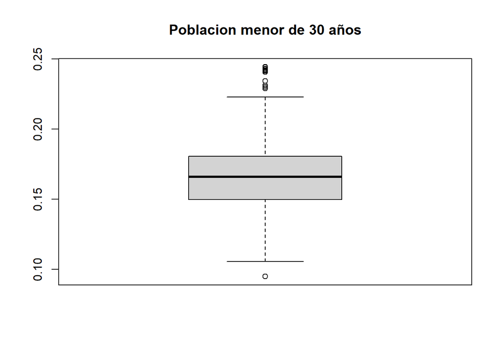

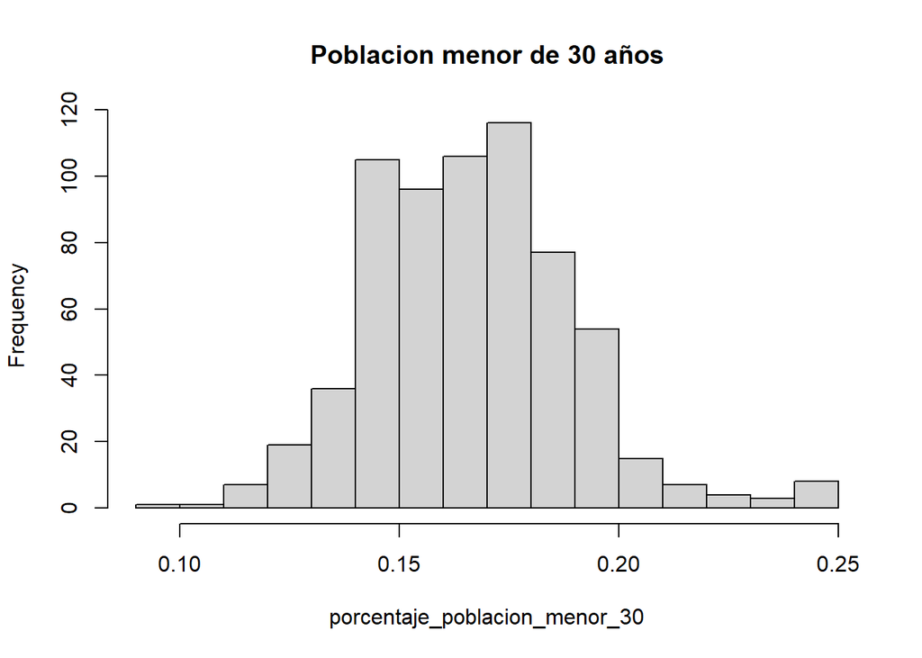

```
##    cod_distrito cod_barrio  año porcentaje_poblacion_menor_30
## 1             1         16 2023                    0.23007289
## 2            14        142 2020                    0.23420888
## 3            14        142 2021                    0.24205225
## 4            14        142 2022                    0.24215176
## 5            14        142 2023                    0.24279707
## 6            19        192 2019                    0.23120535
## 7            19        192 2021                    0.24433481
## 8            19        192 2020                    0.24149081
## 9            19        192 2022                    0.24411883
## 10           19        192 2023                    0.24060363
## 11            4         46 2022                    0.22903245
## 12            4         46 2023                    0.24299118
## 13            8         88 2019                    0.09480849
##                 distrito        barrio
## 1                 Centro           Sol
## 2              Moratalaz       Horcajo
## 3              Moratalaz       Horcajo
## 4              Moratalaz       Horcajo
## 5              Moratalaz       Horcajo
## 6              Vicálvaro Valdebernardo
## 7              Vicálvaro Valdebernardo
## 8              Vicálvaro Valdebernardo
## 9              Vicálvaro Valdebernardo
## 10             Vicálvaro Valdebernardo
## 11             Salamanca    Castellana
## 12             Salamanca    Castellana
## 13 Fuencarral - El Pardo     El Goloso
```

```r
analiza_valores_datset(df_edades_poblacion_menor_30,'porcentaje_poblacion_menor_30', 'Poblacion menor de 30 años', df_nombre_distristros_barrios,c(2,3,1,6))
```

LOs valores extremos altos se observan en algunos barrios céntricos y de la periferia.

Obsevamos que lo mismo ocurre para los datos de poblacion entre 30 y 45 años.

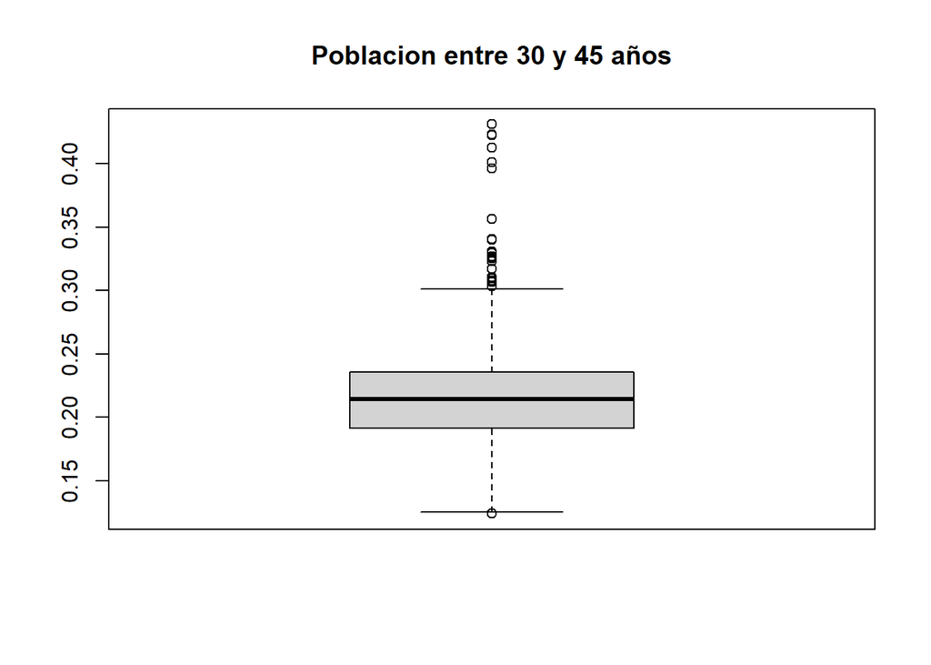

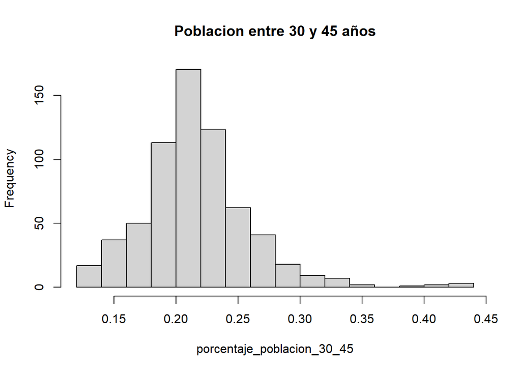

```
##    cod_distrito cod_barrio  año porcentaje_poblacion_30_45          distrito
## 1             1         12 2019                  0.3404406            Centro
## 2             1         12 2020                  0.3399470            Centro
## 3             1         12 2021                  0.3296228            Centro
## 4             1         12 2022                  0.3229158            Centro
## 5             1         12 2023                  0.3253550            Centro
## 6             1         13 2019                  0.3102823            Centro
## 7             1         14 2020                  0.3034856            Centro
## 8             1         15 2022                  0.3105878            Centro
## 9             1         15 2019                  0.3255477            Centro
## 10            1         15 2023                  0.3090717            Centro
## 11            1         15 2020                  0.3267421            Centro
## 12            1         15 2021                  0.3172149            Centro
## 13           10        106 2019                  0.3075852            Latina
## 14           18        183 2022                  0.3064577 Villa de Vallecas
```

[output cut: 33 more lines]

```r
analiza_valores_datset(df_edades_poblacion_30_45,'porcentaje_poblacion_30_45', 'Poblacion entre 30 y 45 años', df_nombre_distristros_barrios, c(2,3,1,6))
```

## 2.2 Nacionalidad extranjera

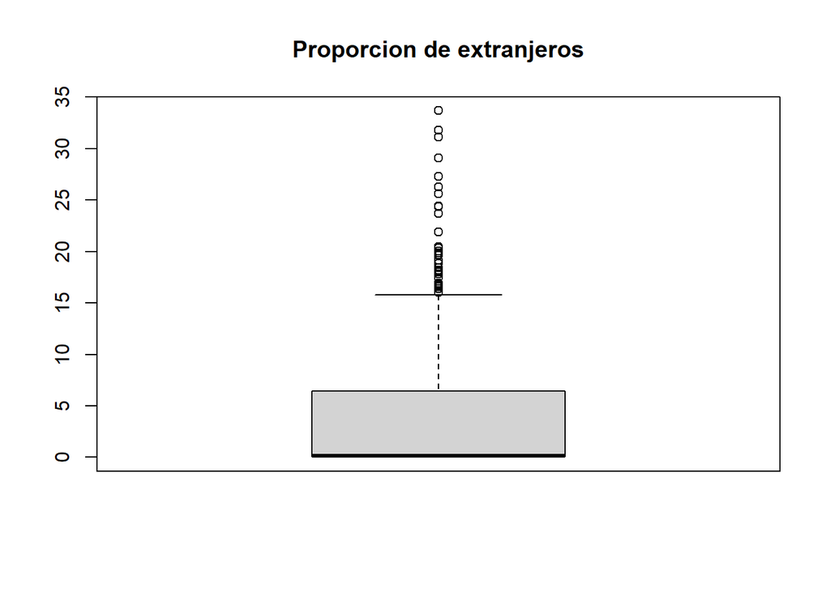

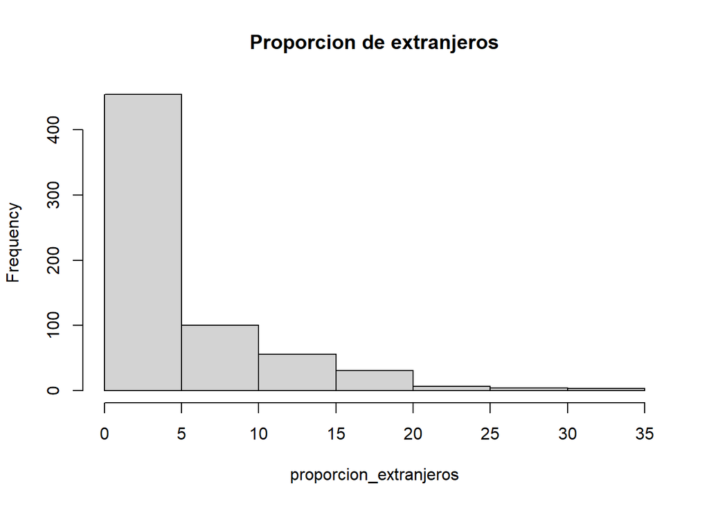

```
##    cod_distrito cod_barrio  año proporcion_extranjeros           distrito
## 1             1         12 2019                  16.93             Centro
## 2             1         12 2020                  18.18             Centro
## 3            10        102 2020                  16.04             Latina
## 4            11        112 2019                  16.89        Carabanchel
## 5            11        112 2020                  18.20        Carabanchel
## 6            11        113 2020                  16.70        Carabanchel
## 7            11        114 2019                  18.13        Carabanchel
## 8            11        114 2020                  20.37        Carabanchel
## 9            11        115 2019                  17.83        Carabanchel
## 10           11        115 2020                  19.86        Carabanchel
## 11           11        117 2020                  18.13        Carabanchel
## 12           12        123 2020                  16.57              Usera
## 13           12        124 2019                  24.41              Usera
## 14           12        124 2020                  26.28              Usera
```

[output cut: 57 more lines]

```r
#df_nacionalidad_extranjera,
#df_nombre_distristros_barrios

analiza_valores_datset(df_nacionalidad_extranjera,'proporcion_extranjeros', 'Proporcion de extranjeros', df_nombre_distristros_barrios, c(2,3,1,4))
```

Se observa gran diferencia entre los valores. Compruebo los años con valores superiores

```r
unique(df_nacionalidad_extranjera[df_nacionalidad_extranjera$proporcion_extranjeros > 1,]$año)
```

```
## [1] 2019 2020
```

```r
head(df_nacionalidad_extranjera[df_nacionalidad_extranjera$proporcion_extranjeros > 1,])
```

```
##    año cod_distrito cod_barrio proporcion_extranjeros
## 1 2019            1         11                   7.95
## 2 2019            1         12                  16.93
## 3 2019            1         13                   9.90
## 4 2019            1         14                   9.93
## 5 2019            1         15                  11.60
## 6 2019            1         16                  13.70
```

```r
head(df_nacionalidad_extranjera[df_nacionalidad_extranjera$proporcion_extranjeros <1,])
```

```
##      año cod_distrito cod_barrio proporcion_extranjeros
## 263 2021            1         11                   0.09
## 264 2021            1         12                   0.19
## 265 2021            1         13                   0.12
## 266 2021            1         14                   0.11
## 267 2021            1         15                   0.13
## 268 2021            1         16                   0.17
```

Se ha utilizado diferente escala para los años 2019-20 y el resto de años. No parece una fuente fiable. Decido cargar la información de otro dataset

Utilizo la información del indicados *“1.1.3.3.B. Población clasificada por Nacionalidad (continente) y Sexo, según Distrito y Barrio (desde el 1 de enero de 2018)”* agregada por sexos.

```r
df_nacionalidad_extranjera_2<-read.csv("../datos/Datos de la serie 0302010300032.csv", sep=";", na.strings="NA",colClasses = "character")
str(df_nacionalidad_extranjera_2)
```

```
## 'data.frame':    912 obs. of  5 variables:
##  $ año      : chr  "1 de enero de 2018" "1 de enero de 2018" "1 de enero de 2018" "1 de enero de 2018" ...
##  $ distrito : chr  "01. Centro" "01. Centro" "01. Centro" "01. Centro" ...
##  $ barrio   : chr  "01. Centro" "011. Palacio" "012. Embajadores" "013. Cortes" ...
##  $ total    : chr  "132.352" "22.515" "44.630" "10.531" ...
##  $ españoles: chr  "103.218" "18.660" "33.354" "8.218" ...
```

Se requiren realizar algunos cambios en el formato numerico de los valores y de los identificadores de distrito y barrio:

```r
df_nacionalidad_extranjera_2 <-
  df_nacionalidad_extranjera_2 %>%
  rename(cod_distrito = distrito, cod_barrio = barrio) %>%
  mutate(
    año = str_sub(año , -4),
    año=as.numeric(año),
    cod_distrito = substr(cod_distrito , 1,2),
    cod_barrio = substr(cod_barrio , 1,3),
    cod_barrio = sub("\\.", "", cod_barrio),
    cod_barrio = as.numeric(cod_barrio),
    cod_distrito = sub("\\.", "", cod_distrito),
    cod_distrito = as.numeric(cod_distrito),
    total = gsub("\\.", "", total),
    total = as.numeric(total),
    españoles = gsub("\\.", "", españoles),
    españoles = as.numeric(españoles)
  )  %>%
  filter(cod_barrio!=cod_distrito)


str(df_nacionalidad_extranjera_2)
```

```
## 'data.frame':    786 obs. of  5 variables:
##  $ año         : num  2018 2018 2018 2018 2018 ...
##  $ cod_distrito: num  1 1 1 1 1 1 2 2 2 2 ...
##  $ cod_barrio  : num  11 12 13 14 15 16 21 22 23 24 ...
##  $ total       : num  22515 44630 10531 16578 30897 ...
##  $ españoles   : num  18660 33354 8218 13168 24422 ...
```

```r
# total por año
datos_por_año <- df_nacionalidad_extranjera_2 %>%
  group_by(año) %>%
  summarise(total = n(), .groups = "drop")

datos_por_año
```

```
## # A tibble: 6 × 2
##     año total
##   <dbl> <int>
## 1  2018   131
## 2  2019   131
## 3  2020   131
## 4  2021   131
## 5  2022   131
## 6  2024   131
```

Se debe restar un año al valor de 2024, ya que se trata del año 2023

```r
df_nacionalidad_extranjera_2$año[df_nacionalidad_extranjera_2$año==2024]<-2023
```

Con estos datos se puede calcular la proporción de extranjeros

```r
df_nacionalidad_extranjera_2$proporcion_extranjeros <- 1 - df_nacionalidad_extranjera_2$españoles/df_nacionalidad_extranjera_2$total
```

Analizo los valores extremos:

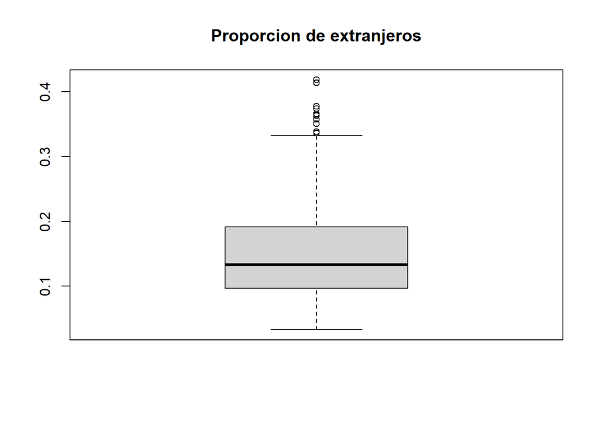

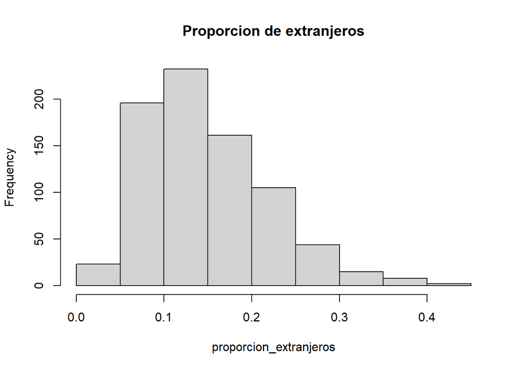

```
##    cod_distrito cod_barrio  año proporcion_extranjeros           distrito
## 1             1         16 2023              0.3776158             Centro
## 2             1         16 2022              0.3364544             Centro
## 3            12        127 2019              0.3387837              Usera
## 4            12        127 2020              0.3640388              Usera
## 5            12        127 2022              0.3661851              Usera
## 6            12        127 2021              0.3774923              Usera
## 7            12        127 2023              0.4185792              Usera
## 8            13        132 2023              0.3738625 Puente de Vallecas
## 9            17        172 2021              0.3633581         Villaverde
## 10           17        172 2020              0.3506924         Villaverde
## 11           17        172 2022              0.3575120         Villaverde
## 12           17        172 2023              0.4143084         Villaverde
##           barrio
## 1            Sol
## 2            Sol
## 3     Pradolongo
## 4     Pradolongo
## 5     Pradolongo
## 6     Pradolongo
## 7     Pradolongo
## 8      San Diego
## 9  San Cristóbal
## 10 San Cristóbal
## 11 San Cristóbal
## 12 San Cristóbal
```

```r
analiza_valores_datset(df_nacionalidad_extranjera_2,'proporcion_extranjeros', 'Proporcion de extranjeros', df_nombre_distristros_barrios,c(2,3,1,6))
```

En este dataset los valores están mejor distribuidos. Se observan valores altos en barrios de los distritos de **Usera, Puente de Vallecas** y **Villaverde**. Estos distrititos se encuentran en la periferia de la ciudad y tradicionalmente han sido receptores de inmigrantes. Sin embargo se observa un valor alto en **Sol**, un barrio ubicado en el distrito **Centro**. Debido a su ubicación este barrio suele estar poblado por las clases altas.

## 2.3 Niveles de estudios

Analiso los datasets *df_estudios, df_universitarios*.

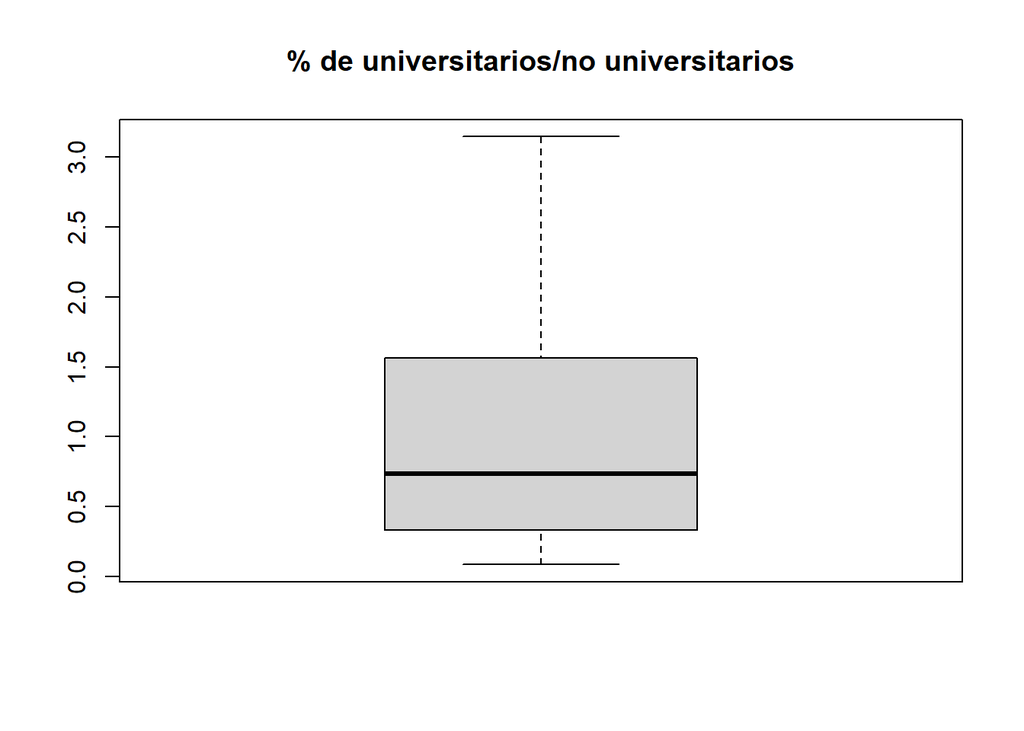

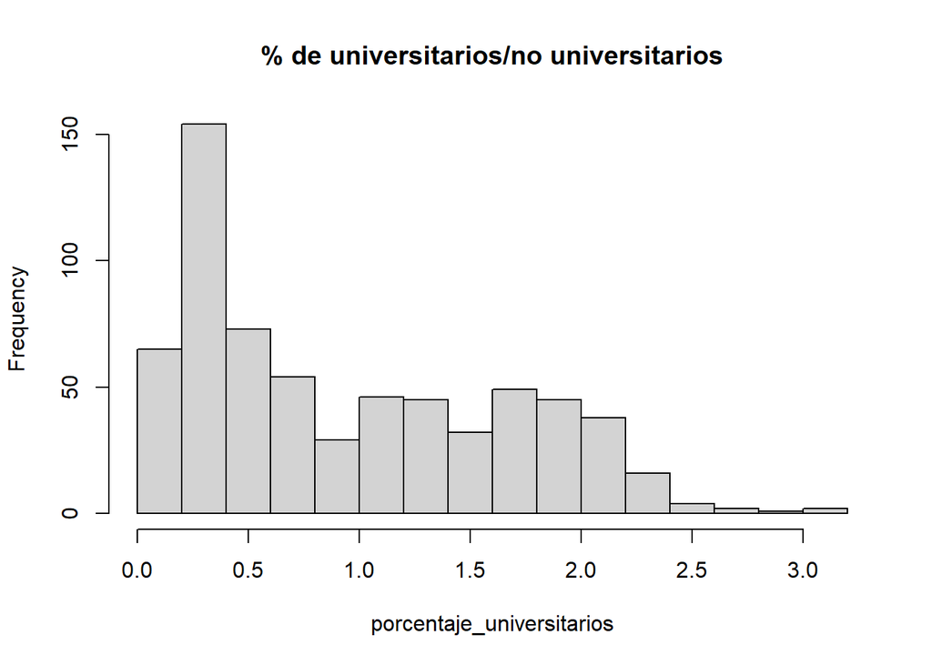

```
## [1] cod_distrito              cod_barrio
## [3] año                       porcentaje_universitarios
## [5] distrito                  barrio
## <0 rows> (or 0-length row.names)
```

```r
analiza_valores_datset(df_estudios,'porcentaje_universitarios', '% de universitarios/no universitarios', df_nombre_distristros_barrios,c(2,3,1,6))
```

No existen valores extremos para el indicador de poblacion con estudios universitarios frente a población sin estudios.

Compruebo el indicados de estudiantes universisarios frente a la población total.

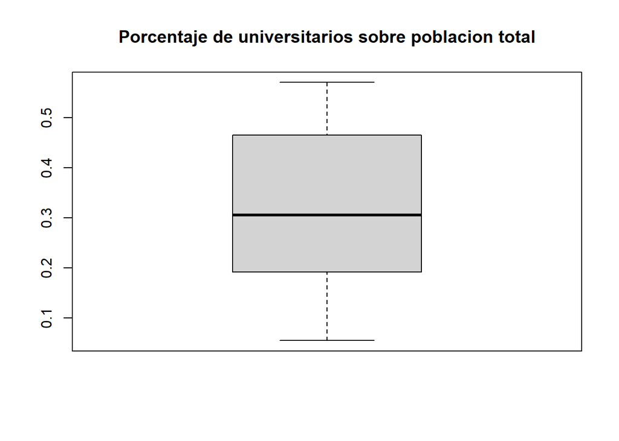

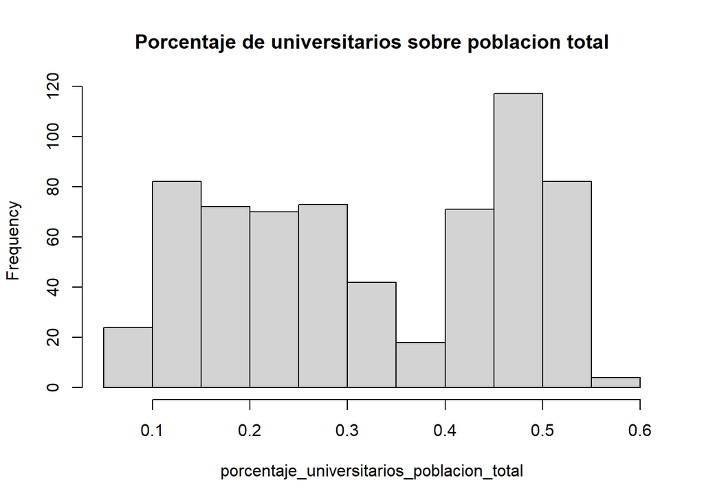

```
## [1] cod_distrito
## [2] cod_barrio
## [3] año
## [4] porcentaje_universitarios_poblacion_total
## [5] distrito
## [6] barrio
## <0 rows> (or 0-length row.names)
```

```r
analiza_valores_datset(df_universitarios,'porcentaje_universitarios_poblacion_total', 'Porcentaje de universitarios sobre poblacion total', df_nombre_distristros_barrios,c(2,3,1,6))
```

Tampoco existen valores extremos

## 2.4 Hogares unipersonales

Añalizo el dataset *indicadores_hogares_unipersonales*

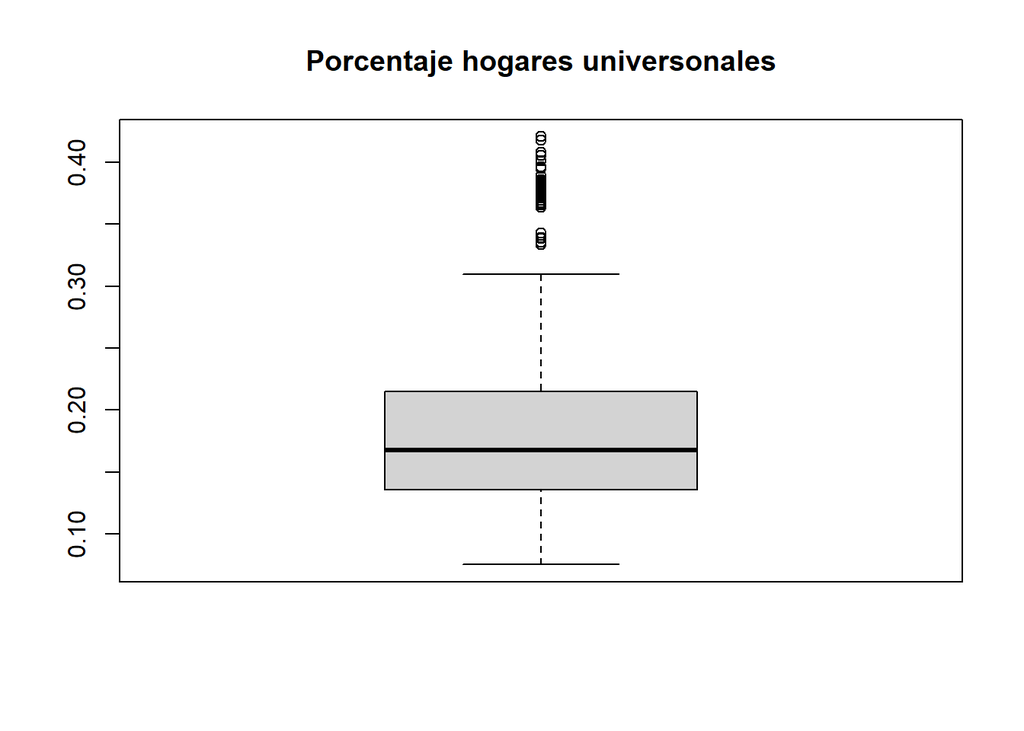

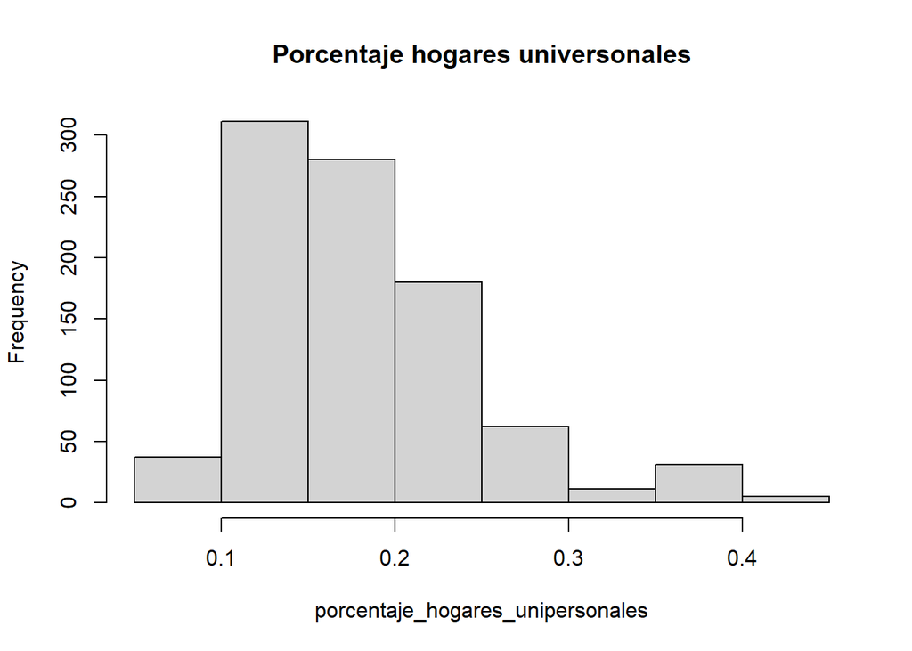

```
##    cod_distrito cod_barrio  año porcentaje_hogares_unipersonales distrito
## 1             1         11 2017                        0.3426224   Centro
## 2             1         11 2020                        0.3338500   Centro
## 3             1         11 2018                        0.3357806   Centro
## 4             1         11 2021                        0.3384405   Centro
## 5             1         11 2022                        0.3392250   Centro
## 6             1         11 2023                        0.3655256   Centro
## 7             1         11 2019                        0.3354917   Centro
## 8             1         12 2017                        0.3748629   Centro
## 9             1         12 2018                        0.3735796   Centro
## 10            1         12 2019                        0.3673551   Centro
## 11            1         12 2022                        0.3846188   Centro
## 12            1         12 2020                        0.3660122   Centro
## 13            1         12 2023                        0.4082254   Centro
## 14            1         12 2021                        0.3765856   Centro
```

[output cut: 73 more lines]

```r
analiza_valores_datset(indicadores_hogares_unipersonales,'porcentaje_hogares_unipersonales', 'Porcentaje hogares universonales', df_nombre_distristros_barrios,c(2,3,1,8))
```

La mayor parte de los valores extremos se encuentran en el distrito **Centro**, los cuales son los candidatos a estar gentrificados. Mantengo estos valores.

# 3 Unificacion de indicadores

En este apartado unifico los indicadores de los diferentes *dataframes* en un único conjunto de datos.

```r
datasets <- c(df_edades_poblacion_30_45, df_edades_poblacion_menor_30, df_nacionalidad_extranjera_2, df_estudios, df_universitarios , indicadores_hogares_unipersonales)


# Inicializo con porcentaje edad entre 30 y 45
df_unificado <- df_edades_poblacion_30_45[,c(1:3,6)]

# Añado porcentaje edad menos de 30
df_unificado$porcentaje_poblacion_menor_30 <- df_edades_poblacion_menor_30$porcentaje_poblacion_menor_30

# Añado porcentaje de extranjeros
df_unificado <- merge(df_unificado, df_nacionalidad_extranjera_2[, c(1:3,6)], by=c("cod_distrito","cod_barrio", 'año'), all.x = TRUE)

# Añado porcentaje poblacion con universitarios frente poblacion sin estudios
df_unificado <- merge(df_unificado, df_estudios[, c(1:3,6)], by=c("cod_distrito","cod_barrio", 'año'), all.x = TRUE)


# Añado porcentaje poblacion con universitarios frente poblacion total
df_unificado <- merge(df_unificado, df_universitarios[, c(1:3,6)], by=c("cod_distrito","cod_barrio", 'año'), all.x = TRUE)


# Añado hogares universionales
df_unificado <- merge(df_unificado, indicadores_hogares_unipersonales[, c(1:3,8)], by=c("cod_distrito","cod_barrio", 'año'), all.x = TRUE)


str(df_unificado)
```

```
## 'data.frame':    655 obs. of  9 variables:
##  $ cod_distrito                             : int  1 1 1 1 1 1 1 1 1 1 ...
##  $ cod_barrio                               : int  11 11 11 11 11 12 12 12 12 12 ...
##  $ año                                      : num  2019 2020 2021 2022 2023 ...
##  $ porcentaje_poblacion_30_45               : num  0.285 0.28 0.27 0.262 0.263 ...
##  $ porcentaje_poblacion_menor_30            : num  0.146 0.157 0.163 0.17 0.174 ...
##  $ proporcion_extranjeros                   : num  0.176 0.185 0.198 0.207 0.238 ...
##  $ porcentaje_universitarios                : num  1.14 1.2 1.24 1.28 1.33 ...
##  $ porcentaje_universitarios_poblacion_total: num  0.454 0.465 0.478 0.479 0.47 ...
##  $ porcentaje_hogares_unipersonales         : num  0.335 0.334 0.338 0.339 0.366 ...
```

Resulta interesante analizar los indicadores en dos momentos del tiempo. Para ello calculo las diferencias entre ambos años:

```r
df_diferencias_23_19 <- df_unificado[df_unificado$año == 2023,c(-3)] - df_unificado[df_unificado$año == 2019,c(-3)]
df_diferencias_23_19$cod_distrito   <-  df_unificado$cod_distrito[df_unificado$año == 2023]
df_diferencias_23_19$cod_barrio   <-  df_unificado$cod_barrio[df_unificado$año == 2023]
str(df_diferencias_23_19)
```

```
## 'data.frame':    131 obs. of  8 variables:
##  $ cod_distrito                             : int  1 1 1 1 1 1 10 10 10 10 ...
##  $ cod_barrio                               : int  11 12 13 14 15 16 101 102 103 104 ...
##  $ porcentaje_poblacion_30_45               : num  -0.0221 -0.0151 -0.0195 -0.0099 -0.0165 ...
##  $ porcentaje_poblacion_menor_30            : num  0.0279 0.022 0.0357 0.0313 0.0296 ...
##  $ proporcion_extranjeros                   : num  0.0618 0.07 0.076 0.0772 0.0686 ...
##  $ porcentaje_universitarios                : num  0.189 0.147 0.281 0.25 0.175 ...
##  $ porcentaje_universitarios_poblacion_total: num  0.01604 0.01466 0.0181 0.01526 0.00922 ...
##  $ porcentaje_hogares_unipersonales         : num  0.03 0.0409 0.0392 0.0461 0.0429 ...
```

## 3.2 Correlaciones

Una vez que están todos los indicadores calculados, es necesario analizar si existe algun tipo de relacion entre ellos. Por ello calculo y visualizo la matrix de correlación.

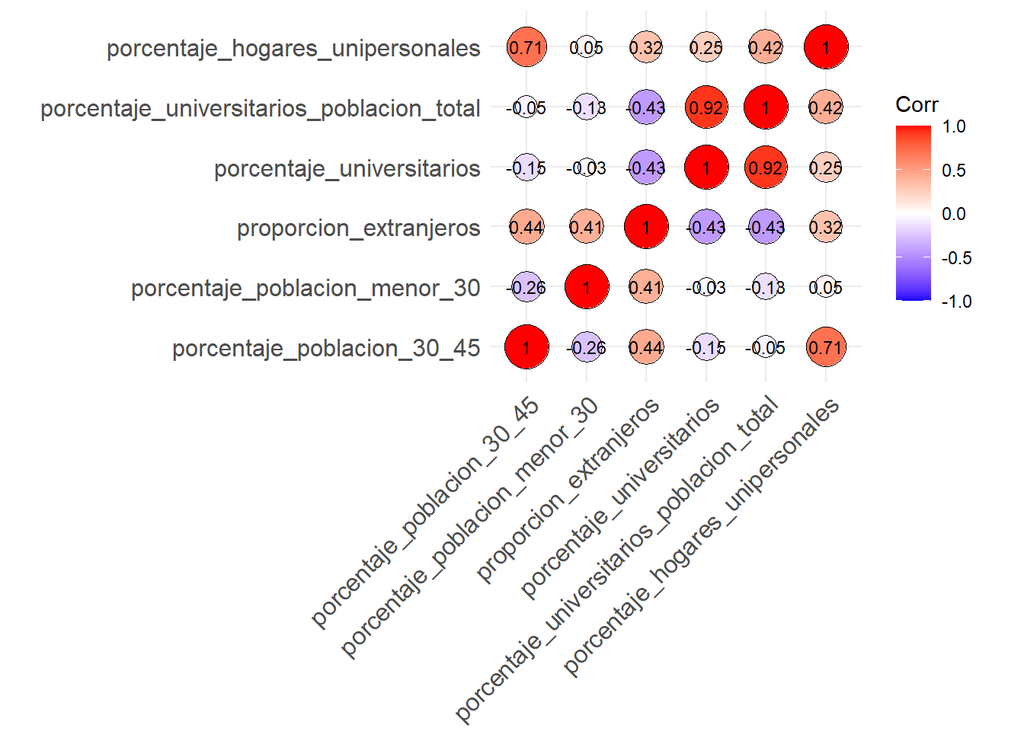

```r
matriz_correlacion <-
  cor(df_unificado[, c(-1:-3)], use = "complete.obs", method = "pearson")


# Grafico de la correlación
ggcorrplot(
  matriz_correlacion,
  lab = TRUE,
  lab_size = 3,
  method = "circle",
  colors = c("blue", "white", "red"),
  outline.color = "black"
)
```

```r
# filtro las variables altamente correlacionadas
matriz_correlacion_fusionada <- melt(matriz_correlacion)
matriz_correlacion_fusionada[abs(matriz_correlacion_fusionada$value) > 0.8 &
                               matriz_correlacion_fusionada$Var1 != matriz_correlacion_fusionada$Var2,]
```

```
##                                         Var1
## 23 porcentaje_universitarios_poblacion_total
## 28                 porcentaje_universitarios
##                                         Var2     value
## 23                 porcentaje_universitarios 0.9183741
## 28 porcentaje_universitarios_poblacion_total 0.9183741
```

Prescindo del indicador *porcentaje_universitarios*

```r
df_unificado <- df_unificado[,c(-7)]
str(df_unificado)
```

```
## 'data.frame':    655 obs. of  8 variables:
##  $ cod_distrito                             : int  1 1 1 1 1 1 1 1 1 1 ...
##  $ cod_barrio                               : int  11 11 11 11 11 12 12 12 12 12 ...
##  $ año                                      : num  2019 2020 2021 2022 2023 ...
##  $ porcentaje_poblacion_30_45               : num  0.285 0.28 0.27 0.262 0.263 ...
##  $ porcentaje_poblacion_menor_30            : num  0.146 0.157 0.163 0.17 0.174 ...
##  $ proporcion_extranjeros                   : num  0.176 0.185 0.198 0.207 0.238 ...
##  $ porcentaje_universitarios_poblacion_total: num  0.454 0.465 0.478 0.479 0.47 ...
##  $ porcentaje_hogares_unipersonales         : num  0.335 0.334 0.338 0.339 0.366 ...
```

## 3.3 Normalización

Para obtener mejores resultados en la clasificacion kmeans es recomendable normalizar los valores de los indicidadores:

```r
str(df_unificado)
```

```
## 'data.frame':    655 obs. of  8 variables:
##  $ cod_distrito                             : int  1 1 1 1 1 1 1 1 1 1 ...
##  $ cod_barrio                               : int  11 11 11 11 11 12 12 12 12 12 ...
##  $ año                                      : num  2019 2020 2021 2022 2023 ...
##  $ porcentaje_poblacion_30_45               : num  0.285 0.28 0.27 0.262 0.263 ...
##  $ porcentaje_poblacion_menor_30            : num  0.146 0.157 0.163 0.17 0.174 ...
##  $ proporcion_extranjeros                   : num  0.176 0.185 0.198 0.207 0.238 ...
##  $ porcentaje_universitarios_poblacion_total: num  0.454 0.465 0.478 0.479 0.47 ...
##  $ porcentaje_hogares_unipersonales         : num  0.335 0.334 0.338 0.339 0.366 ...
```

```r
normalizar <- function(x) {
  (x - min(x, na.rm = TRUE)) / (max(x, na.rm = TRUE) - min(x, na.rm = TRUE))
}
columnas_a_normalizar <- c(4:8)
df_normalizado <- df_unificado
df_normalizado[columnas_a_normalizar] <- lapply(df_normalizado[columnas_a_normalizar], normalizar)

str(df_normalizado)
```

```
## 'data.frame':    655 obs. of  8 variables:
##  $ cod_distrito                             : int  1 1 1 1 1 1 1 1 1 1 ...
##  $ cod_barrio                               : int  11 11 11 11 11 12 12 12 12 12 ...
##  $ año                                      : num  2019 2020 2021 2022 2023 ...
##  $ porcentaje_poblacion_30_45               : num  0.525 0.509 0.476 0.449 0.453 ...
##  $ porcentaje_poblacion_menor_30            : num  0.345 0.419 0.458 0.503 0.532 ...
##  $ proporcion_extranjeros                   : num  0.366 0.391 0.423 0.447 0.527 ...
##  $ porcentaje_universitarios_poblacion_total: num  0.775 0.795 0.822 0.823 0.806 ...
##  $ porcentaje_hogares_unipersonales         : num  0.753 0.749 0.762 0.764 0.84 ...
```

# 4 Clasificación de barrios segun indicadores

En primer lugar identifico visualmente el número de *clusters* por el método del codo y de la silueta:

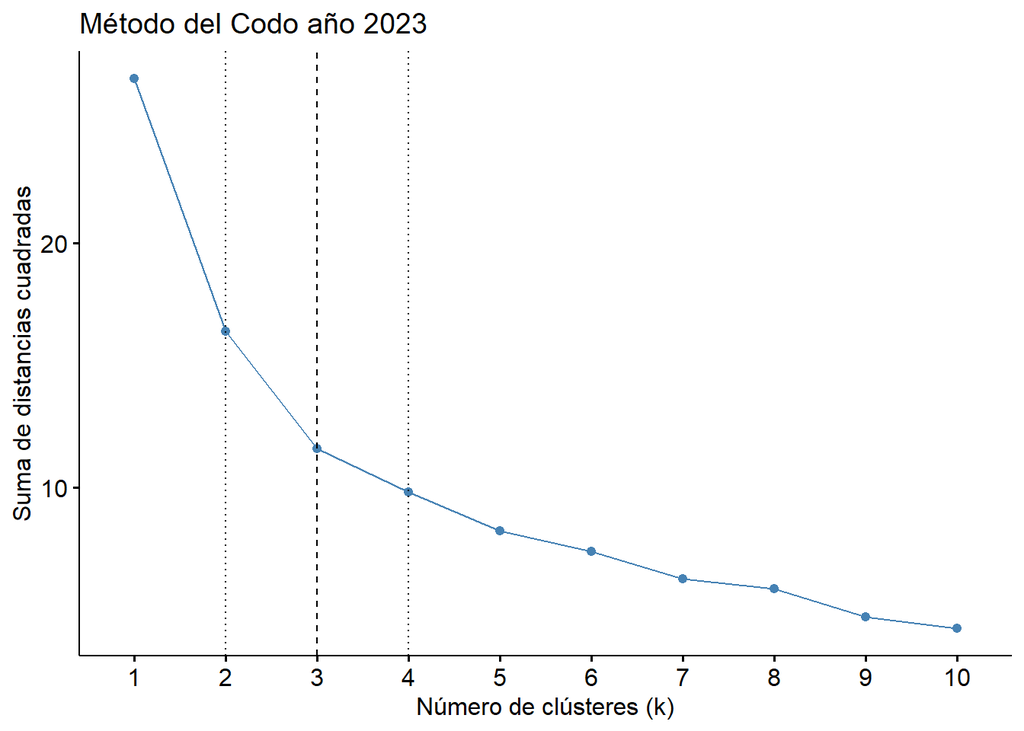

```r
# fijado de semila de aleatoreidad
set.seed(20)
# Método del codo
fviz_nbclust(df_normalizado[df_normalizado$año == 2023, c(-1:-3)], kmeans, method = "wss") +
  labs(title = "Método del Codo año 2023", x = "Número de clústeres (k)", y = "Suma de distancias cuadradas") + geom_vline(xintercept = 3, linetype = 2) + geom_vline(xintercept = 4, linetype = 3) + geom_vline(xintercept = 2, linetype = 3)
```

Metodo silueta.

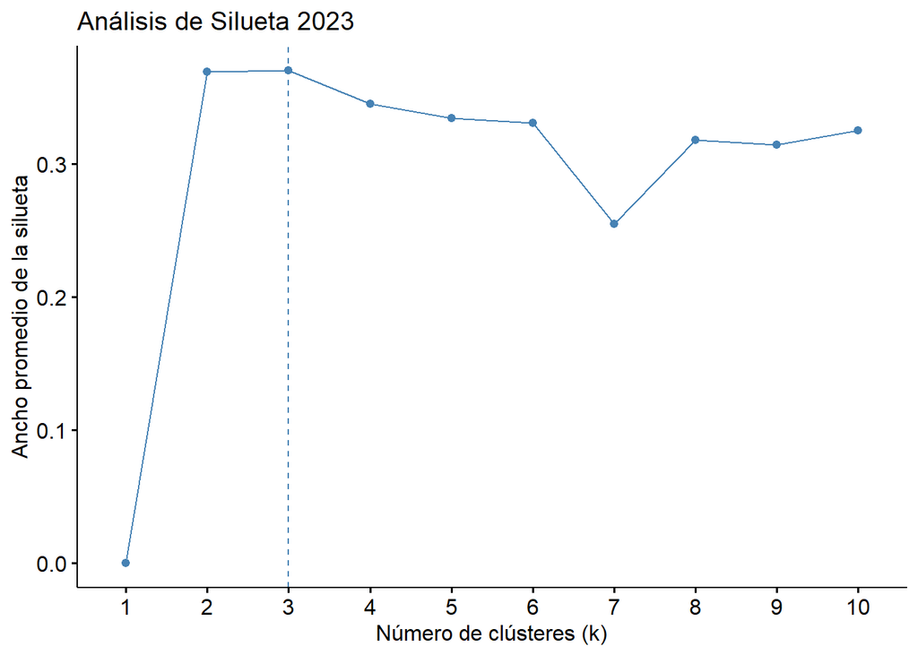

```r
set.seed(20)
# Calcular el análisis de silueta
fviz_nbclust(df_normalizado[df_normalizado$año == 2023, c(-1:-3)] , kmeans, method = "silhouette") +
  labs(title = "Análisis de Silueta 2023", x = "Número de clústeres (k)", y = "Ancho promedio de la silueta")
```

Aplico el algotitmo de division para k = 3.

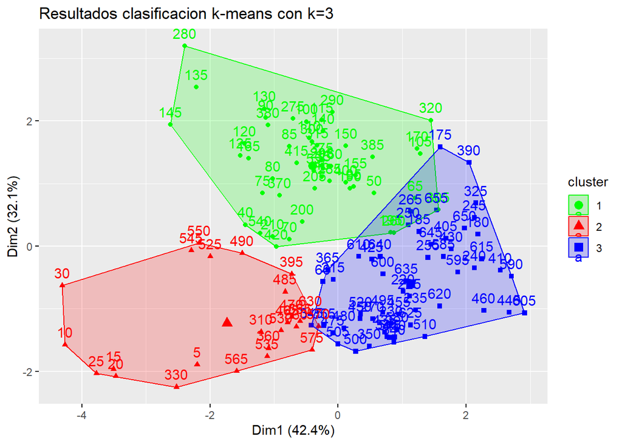

```r
set.seed(20)
k <- 3
df_cluster <- df_normalizado[df_normalizado$año==2023,]
resultado_kmeans <- kmeans(df_cluster[c(-1:-3)], centers = k, nstart = 10)
# Visualización
fviz_cluster(resultado_kmeans, data =df_cluster[,c(-1:-3)], palette = c("green", "red", "blue")) +
  labs(title = "Resultados clasificacion k-means con k=3")
```

```r
df_cluster$cluster <- resultado_kmeans$cluster
```

# 5 Añálisis incial en un mapa de Carto

En Carto genero un mapa con la información de los indicadores de barrios, asi como la agrupacion kmeans.

Para ello, en primer lugar cargo el mapa de los barrios de Madrid:

```r
# Mapa de barrios

ruta_shapefile <- "../mapa/Barrios/barrios.shp"
mapa_barrios <- st_read(ruta_shapefile)
str(mapa_barrios)
```

```
## Classes 'sf' and 'data.frame':   131 obs. of  12 variables:
##  $ CODDIS    : chr  "1" "1" "1" "1" ...
##  $ NOMDIS    : chr  "Centro" "Centro" "Centro" "Centro" ...
##  $ COD_BAR   : chr  "011" "012" "013" "014" ...
##  $ NOMBRE    : chr  "Palacio" "Embajadores" "Cortes" "Justicia" ...
##  $ Shape_Leng: num  0 0 0 0 0 0 0 0 0 0 ...
##  $ COD_DIS_TX: chr  "01" "01" "01" "01" ...
##  $ BARRIO_MAY: chr  "PALACIO" "EMBAJADORES" "CORTES" "JUSTICIA" ...
##  $ COD_DISBAR: chr  "11" "12" "13" "14" ...
##  $ NUM_BAR   : chr  "1" "2" "3" "4" ...
##  $ BARRIO_MT : chr  "PALACIO" "EMBAJADORES" "CORTES" "JUSTICIA" ...
##  $ COD_DISB  : chr  "1-1" "1-2" "1-3" "1-4" ...
##  $ geometry  :sfc_POLYGON of length 131; first list element: List of 1
##   ..$ : num [1:81, 1:2] 440113 440078 439927 439944 439937 ...
##   ..- attr(*, "class")= chr [1:3] "XY" "POLYGON" "sfg"
##  - attr(*, "sf_column")= chr "geometry"
##  - attr(*, "agr")= Factor w/ 3 levels "constant","aggregate",..: NA NA NA NA NA NA NA NA NA NA ...
##   ..- attr(*, "names")= chr [1:11] "CODDIS" "NOMDIS" "COD_BAR" "NOMBRE" ...
```

Modifico el nombre de la variable de codigo de barrio y codigo de distrito para poder hacer el cruce de datos con el dataset que he preparado:

```r
df_mapa_barrios <- mapa_barrios %>%
  rename(cod_barrio = COD_BAR, cod_distrito = CODDIS)

str(df_mapa_barrios)
```

```
## Classes 'sf' and 'data.frame':   131 obs. of  12 variables:
##  $ cod_distrito: chr  "1" "1" "1" "1" ...
##  $ NOMDIS      : chr  "Centro" "Centro" "Centro" "Centro" ...
##  $ cod_barrio  : chr  "011" "012" "013" "014" ...
##  $ NOMBRE      : chr  "Palacio" "Embajadores" "Cortes" "Justicia" ...
##  $ Shape_Leng  : num  0 0 0 0 0 0 0 0 0 0 ...
##  $ COD_DIS_TX  : chr  "01" "01" "01" "01" ...
##  $ BARRIO_MAY  : chr  "PALACIO" "EMBAJADORES" "CORTES" "JUSTICIA" ...
##  $ COD_DISBAR  : chr  "11" "12" "13" "14" ...
##  $ NUM_BAR     : chr  "1" "2" "3" "4" ...
##  $ BARRIO_MT   : chr  "PALACIO" "EMBAJADORES" "CORTES" "JUSTICIA" ...
##  $ COD_DISB    : chr  "1-1" "1-2" "1-3" "1-4" ...
##  $ geometry    :sfc_POLYGON of length 131; first list element: List of 1
##   ..$ : num [1:81, 1:2] 440113 440078 439927 439944 439937 ...
##   ..- attr(*, "class")= chr [1:3] "XY" "POLYGON" "sfg"
##  - attr(*, "sf_column")= chr "geometry"
##  - attr(*, "agr")= Factor w/ 3 levels "constant","aggregate",..: NA NA NA NA NA NA NA NA NA NA ...
##   ..- attr(*, "names")= chr [1:11] "cod_distrito" "NOMDIS" "cod_barrio" "NOMBRE" ...
```

## 5.1 Incorporación de datos al mapa

Renombro la variable cluster a grado de gentrificación. En este momento aun no sé identificar que grupo corresponde a cada grado de gentrificación. A partir de la visualizacion en el mapa y análisis de los indicadores descrubriré que grupo corresponde con cada nivel:

```r
df_datos_2023 <- df_cluster %>%
  rename(grado_gentrificacion = cluster) %>%
  select(-año)
str(df_datos_2023)
```

```
## 'data.frame':    131 obs. of  8 variables:
##  $ cod_distrito                             : int  1 1 1 1 1 1 10 10 10 10 ...
##  $ cod_barrio                               : int  11 12 13 14 15 16 101 102 103 104 ...
##  $ porcentaje_poblacion_30_45               : num  0.453 0.656 0.543 0.537 0.603 ...
##  $ porcentaje_poblacion_menor_30            : num  0.532 0.618 0.644 0.663 0.67 ...
##  $ proporcion_extranjeros                   : num  0.527 0.775 0.708 0.667 0.649 ...
##  $ porcentaje_universitarios_poblacion_total: num  0.806 0.667 0.892 0.9 0.823 ...
##  $ porcentaje_hogares_unipersonales         : num  0.84 0.964 0.957 0.991 1 ...
##  $ grado_gentrificacion                     : int  2 2 2 2 2 2 1 1 1 1 ...
```

Pivoto las variables de los indicadores y grado de gentrificación para juntarlas todas en una misma columna:

```r
df_datos_2023$cod_barrio <- str_pad(as.character(df_datos_2023$cod_barrio), width = 3, pad = "0")

df_datos_2023_mapa <- df_datos_2023 %>%
  mutate(cod_barrio = str_pad(as.character(cod_barrio), width = 3, pad = "0"))  %>%
  pivot_longer(
    cols = 3:8,
    names_to = "indicador",
    values_to = "valor_indicador"
  )

str(df_datos_2023_mapa)
```

```
## tibble [786 × 4] (S3: tbl_df/tbl/data.frame)
##  $ cod_distrito   : int [1:786] 1 1 1 1 1 1 1 1 1 1 ...
##  $ cod_barrio     : chr [1:786] "011" "011" "011" "011" ...
##  $ indicador      : chr [1:786] "porcentaje_poblacion_30_45" "porcentaje_poblacion_menor_30" "proporcion_extranjeros" "porcentaje_universitarios_poblacion_total" ...
##  $ valor_indicador: num [1:786] 0.453 0.532 0.527 0.806 0.84 ...
```

Incorporo los datos al mapa

```r
df_mapa_barrios <- df_mapa_barrios %>%
  left_join(df_datos_2023_mapa, by = "cod_barrio")
```

Exporto el fichero de mapa con datos:

```r
ruta_fichero_mapa_barrios  <- "../mapa/Barrios/barrios_con_indicadores_2023.shp"
st_write(df_mapa_barrios, ruta_fichero_mapa_barrios, append=FALSE)
```

```
## Deleting layer `barrios_con_indicadores_2023' using driver `ESRI Shapefile'
## Writing layer `barrios_con_indicadores_2023' to data source
##   `../mapa/Barrios/barrios_con_indicadores_2023.shp' using driver `ESRI Shapefile'
## Writing 786 features with 14 fields and geometry type Polygon.
```

## 5.2 Información del mapa en carto

Genero un primer mapa de Clasificación kmeans de barrios según indicadores de gentrificación

El mapa se compone de 2 capas:

- La capa superior muestra la agrupación de barrios en base a los indicadores de gentrificación utilizados. El número de grupos utilizados es 3.
- la capa inferior muestra los valores del indicador seleccionado en la pestaña de **Parámetro**

Se pueden mostrar y ocultar cada una de las capas.

Los 2 iconos ubicados en la parte superior derecha del mapa permiten intercambiar la visualización de esta descripción y la sección de parámetros y widgets

### 5.2.1 Parámetro de tipo de indicador

La selección del indicador mostrado en la capa de indicadores se hace en la pestaña *parameters*. Este parámetro modifica dinámicamente la consulta SQL a la tabla de datos, permitiendo visualizar uno de los 5 indicadores utilizados en la capa *Indicador*. Los widgets de la capa *Indicador* son actualizados automáticamente con la selección de este parámetro. Para la correcta visualización de datos es importante seleccionar únicamente un solo indicador del combo de selección

Los valores posibles son:

```r
sort(unique(df_mapa_barrios$indicador))
```

```
## [1] "grado_gentrificacion"
## [2] "porcentaje_hogares_unipersonales"
## [3] "porcentaje_poblacion_30_45"
## [4] "porcentaje_poblacion_menor_30"
## [5] "porcentaje_universitarios_poblacion_total"
## [6] "proporcion_extranjeros"
```

### 5.2.2 Widgets

He añadido los siguientes *widgets* al mapa, los cuales permiten interactuar dinámicamente con cada capa del mapa.

#### 5.2.2.1 Capa de agrupación:

- **Agrupacion kmeans**. Permite seleccionar las agrupaciones a visualizar en el mapa
- **Selector de barrios** según grupo de clasificación
- **Tabla clasificación gentrificación**. Permite visualizar y buscar por barrios, distritos y grupo de gentrificación.

#### 5.2.2.2 Capa de indicador

- **Distribución del indicador.** Permite seleccionar los barrios visualizados en función del valor de su indicador.
- **Tabla de indicadores.** Permite visualizar y buscar por por barrios, distritos e indicador seleccionado.

El mapa está publicado en https://pinea.app.carto.com/map/4aced469-f471-438e-8050-1f6b26d874d2

# 6 Conclusiones iniciales

El mapa generado tiene 2 capas. La capa superior contiene la division de barrios generada por el algoritmo de kmeans. Los barrios céntricos están agrupados en un mismo cluster. La gentrificación tradicionalmente se produce en barrios céntricos. Esto nos hace pensar que este grupo es el que presenta mayor grado de gentrificación. Observo el valor medio de los indicadores por grupo de barrios:

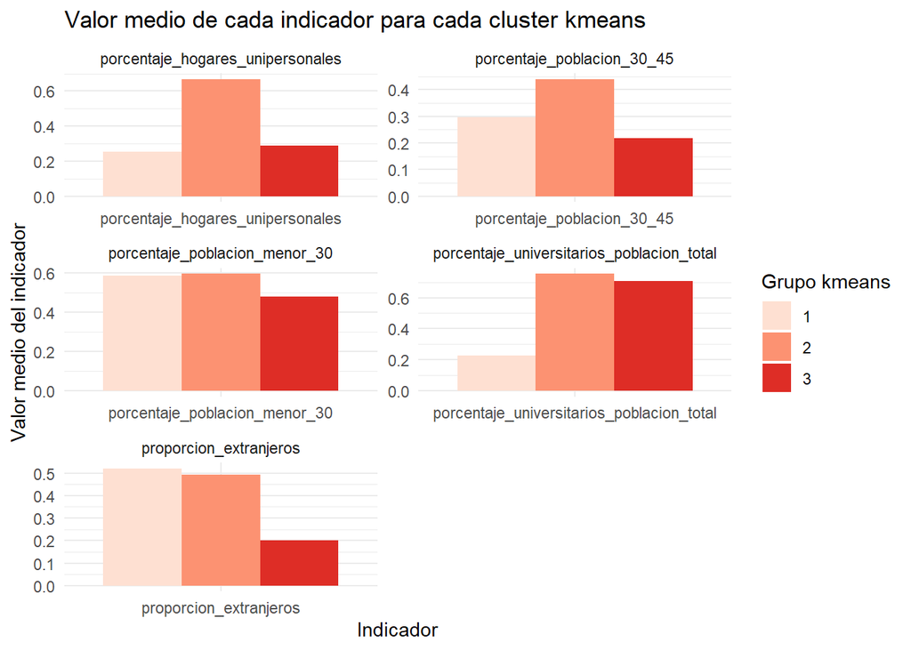

```r
df_cluster_resumen <- df_cluster %>%
  group_by(cluster) %>%
  summarise(across(4:8, mean))  %>%
  pivot_longer(cols = -cluster, names_to = "indicador", values_to = "valor_medio")


# Gráfico
ggplot(df_cluster_resumen, aes(x = indicador, y = valor_medio, fill = as.factor(cluster))) +
  geom_bar(stat = "identity", position = "dodge") +
  facet_wrap(~indicador, scales = "free", ncol = 2) +
  labs(
    title = "Valor medio de cada indicador para cada cluster kmeans",
    x = "Indicador",
    y = "Valor medio del indicador",
    fill = "Grupo kmeans"
  ) +
  theme_minimal() +
  scale_fill_brewer(palette = "Reds")
```

El *cluster* 2 contiene el mayor indicador medio de hogares unipersonales, población menor de 30 y entre 30 - 45, población con estudios universitarrios. El porcentaje de extranjeros es alto, similar al cluster 1.

En el mapa se observan algunos barrios de la periferia clasificados en el cluster 2. Estos son:

- *Rejas*
- *El Cañaveral*
- *Ensanche de Vallecas*

Vemos los indicadores de estos barrios en comparación con el valor medio del grupo:

```r
df_cluster_periferia <-df_cluster[df_cluster$cod_barrio %in% c(206, 183, 194),c(2,4:8)]

df_cluster_periferia
```

```
##     cod_barrio porcentaje_poblacion_30_45 porcentaje_poblacion_menor_30
## 310        183                  0.5414134                     0.3299774
## 330        194                  0.9737433                     0.1629674
## 395        206                  0.3464357                     0.4862077
##     proporcion_extranjeros porcentaje_universitarios_poblacion_total
## 310              0.3110048                                 0.4436440
## 330              0.2841185                                 0.4177181
## 395              0.4604195                                 0.5400685
##     porcentaje_hogares_unipersonales
## 310                        0.5741736
## 330                        0.4824014
## 395                        0.4832136
```

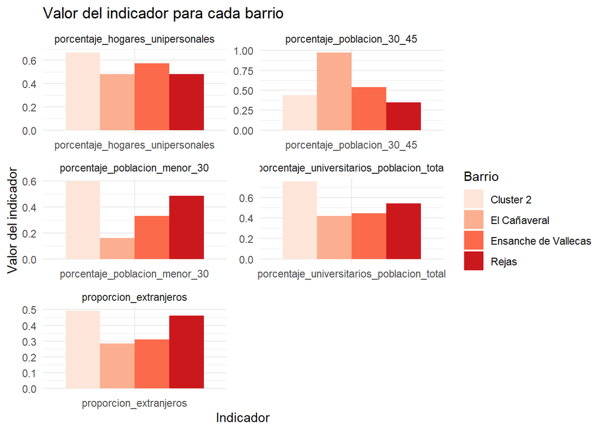

```r
df_cluster_periferia <- merge(
  df_cluster_periferia,
  df_nombre_distristros_barrios,
  by = c("cod_barrio"),
  all.x = TRUE
)

df_cluster_periferia_pivotado <- df_cluster_periferia[c(2:6,9)] %>%
  pivot_longer(
    cols = -barrio,
    names_to = "indicador",
    values_to = "valor"
  )

df_valor_medio <- df_cluster_resumen[df_cluster_resumen$cluster==2,c(2:3)] %>%
  rename(valor=valor_medio)
# añado valor ficticio
df_valor_medio$barrio <- 'Cluster 2'

df <- rbind(df_cluster_periferia_pivotado, df_valor_medio)


ggplot(df, aes(x = indicador, y = valor, fill = as.factor(barrio))) +
  geom_bar(stat = "identity", position = "dodge") +
  facet_wrap(~indicador, scales = "free", ncol = 2) +
  labs(
    title = "Valor del indicador para cada barrio",
    x = "Indicador",
    y = "Valor del indicador",
    fill = "Barrio"
  ) +
  theme_minimal() +
  scale_fill_brewer(palette = "Reds")
```

Concluyo Por todo esto se deduce que el grado de gentrificación es alto en el grupo 2, medio en el grupo 3 y bajo en el grupo 1.

Para facilitar la interpretación en el mapa asocio el valor 3 al cluster de barrios con alta gentrificación, 2 al medio y 1 al bajo.

```r
df_cluster <- df_cluster  %>%
  mutate(grado = case_when(cluster == 1 ~ 1,
                           cluster == 2 ~ 3,
                           cluster == 3 ~ 2))
str(df_cluster)
```

```
## 'data.frame':    131 obs. of  10 variables:
##  $ cod_distrito                             : int  1 1 1 1 1 1 10 10 10 10 ...
##  $ cod_barrio                               : int  11 12 13 14 15 16 101 102 103 104 ...
##  $ año                                      : num  2023 2023 2023 2023 2023 ...
##  $ porcentaje_poblacion_30_45               : num  0.453 0.656 0.543 0.537 0.603 ...
##  $ porcentaje_poblacion_menor_30            : num  0.532 0.618 0.644 0.663 0.67 ...
##  $ proporcion_extranjeros                   : num  0.527 0.775 0.708 0.667 0.649 ...
##  $ porcentaje_universitarios_poblacion_total: num  0.806 0.667 0.892 0.9 0.823 ...
##  $ porcentaje_hogares_unipersonales         : num  0.84 0.964 0.957 0.991 1 ...
##  $ cluster                                  : int  2 2 2 2 2 2 1 1 1 1 ...
##  $ grado                                    : num  3 3 3 3 3 3 1 1 1 1 ...
```

# 7 Mapa de evolución de indicadores y grado de gentrificación

Para ver la evolución de los indicadores a lo largo del periodo de estudio utilizo el conjunto de datos *df_diferencias_23_19* creado anteriormente, al que añado la variable grado gentrificación. Marco este conjunto de datos como tipo *variación*. Esta marca sirve para filtar los datos en la consulta de datos de carto.

```r
df_diferencias_23_19 <- merge(df_diferencias_23_19[, c(-6)], df_cluster[,c(1:3, 10)], by=c('cod_distrito', 'cod_barrio'), all = TRUE)
# añado variable tipo para utilizarlo en el mapa
df_diferencias_23_19$tipo <- "variacion"
str(df_diferencias_23_19)
```

```
## 'data.frame':    131 obs. of  10 variables:
##  $ cod_distrito                             : int  1 1 1 1 1 1 10 10 10 10 ...
##  $ cod_barrio                               : int  11 12 13 14 15 16 101 102 103 104 ...
##  $ porcentaje_poblacion_30_45               : num  -0.0221 -0.0151 -0.0195 -0.0099 -0.0165 ...
##  $ porcentaje_poblacion_menor_30            : num  0.0279 0.022 0.0357 0.0313 0.0296 ...
##  $ proporcion_extranjeros                   : num  0.0618 0.07 0.076 0.0772 0.0686 ...
##  $ porcentaje_universitarios_poblacion_total: num  0.01604 0.01466 0.0181 0.01526 0.00922 ...
##  $ porcentaje_hogares_unipersonales         : num  0.03 0.0409 0.0392 0.0461 0.0429 ...
##  $ año                                      : num  2023 2023 2023 2023 2023 ...
##  $ grado                                    : num  3 3 3 3 3 3 1 1 1 1 ...
##  $ tipo                                     : chr  "variacion" "variacion" "variacion" "variacion" ...
```

Añado a este dataset el conjunto de indicadores para el periodo 2019-2023. El tipo de estos datos es *total*

```r
df_mapa_total_y_diferencias <- df_unificado
# marcado de tipo de dato
df_mapa_total_y_diferencias$tipo <- "total"
# valor ficticio
df_mapa_total_y_diferencias$grado <- 0
df_mapa_total_y_diferencias <- rbind(df_mapa_total_y_diferencias, df_diferencias_23_19)

str(df_mapa_total_y_diferencias)
```

```
## 'data.frame':    786 obs. of  10 variables:
##  $ cod_distrito                             : int  1 1 1 1 1 1 1 1 1 1 ...
##  $ cod_barrio                               : int  11 11 11 11 11 12 12 12 12 12 ...
##  $ año                                      : num  2019 2020 2021 2022 2023 ...
##  $ porcentaje_poblacion_30_45               : num  0.285 0.28 0.27 0.262 0.263 ...
##  $ porcentaje_poblacion_menor_30            : num  0.146 0.157 0.163 0.17 0.174 ...
##  $ proporcion_extranjeros                   : num  0.176 0.185 0.198 0.207 0.238 ...
##  $ porcentaje_universitarios_poblacion_total: num  0.454 0.465 0.478 0.479 0.47 ...
##  $ porcentaje_hogares_unipersonales         : num  0.335 0.334 0.338 0.339 0.366 ...
##  $ tipo                                     : chr  "total" "total" "total" "total" ...
##  $ grado                                    : num  0 0 0 0 0 0 0 0 0 0 ...
```

Pivoto los datos para añadirlo al mapa

```r
df_mapa_total_y_diferencias_mapa <- df_mapa_total_y_diferencias %>%
  mutate(cod_barrio = str_pad(as.character(cod_barrio), width = 3, pad = "0"))  %>%
  pivot_longer(
    cols = 4:8,
    names_to = "indicador",
    values_to = "valor_indicador"
  )

str(df_mapa_total_y_diferencias_mapa)
```

```
## tibble [3,930 × 7] (S3: tbl_df/tbl/data.frame)
##  $ cod_distrito   : int [1:3930] 1 1 1 1 1 1 1 1 1 1 ...
##  $ cod_barrio     : chr [1:3930] "011" "011" "011" "011" ...
##  $ año            : num [1:3930] 2019 2019 2019 2019 2019 ...
##  $ tipo           : chr [1:3930] "total" "total" "total" "total" ...
##  $ grado          : num [1:3930] 0 0 0 0 0 0 0 0 0 0 ...
##  $ indicador      : chr [1:3930] "porcentaje_poblacion_30_45" "porcentaje_poblacion_menor_30" "proporcion_extranjeros" "porcentaje_universitarios_poblacion_total" ...
##  $ valor_indicador: num [1:3930] 0.285 0.146 0.176 0.454 0.335 ...
```

Genero el fichero del mapa

```r
# Mapa de barrios
ruta_shapefile <- "../mapa/Barrios/barrios.shp"
mapa_barrios <- st_read(ruta_shapefile)
df_mapa_barrios <- mapa_barrios %>%
  rename(cod_barrio = COD_BAR, cod_distrito = CODDIS)
```

Incorporo los datos al mapa

```r
df_mapa_barrios <- df_mapa_barrios %>%
  left_join(df_mapa_total_y_diferencias_mapa, by = "cod_barrio")
```

Exporto el fichero de mapa con datos:

```r
ruta_fichero_mapa_barrios  <- "../mapa/Barrios/barrios_indicadores_total_y_variacion.shp"
st_write(df_mapa_barrios, ruta_fichero_mapa_barrios, append=FALSE)
```

```
## Deleting layer `barrios_indicadores_total_y_variacion' using driver `ESRI Shapefile'
## Writing layer `barrios_indicadores_total_y_variacion' to data source
##   `../mapa/Barrios/barrios_indicadores_total_y_variacion.shp' using driver `ESRI Shapefile'
## Writing 3930 features with 17 fields and geometry type Polygon.
```

```r
df_cuenta <- df_nacionalidad_extranjera[df_nacionalidad_extranjera$año==2023, c(2,3)]
df_cuenta %>%
  group_by(cod_distrito ) %>%
  summarise(barrios_por_distrito = n())  %>%
arrange(desc(barrios_por_distrito))
```

```
## # A tibble: 21 × 2
##    cod_distrito barrios_por_distrito
##           <int>                <int>
##  1           15                    9
##  2            8                    8
##  3           20                    8
##  4            2                    7
##  5            9                    7
##  6           10                    7
##  7           11                    7
##  8           12                    7
##  9            1                    6
## 10            3                    6
## # ℹ 11 more rows
```

## 7.1 Información del mapa de carto

He generado el mapa denoninado *Clasificación de barrios según indicadores de gentrificación*

El mapa está publicado en https://pinea.app.carto.com/map/5847c277-513e-4931-8e5c-b2efc0788f8e

El mapa se compone de 3 capas:

- La capa superior muestra los barrios con su grado de gentrificación. Se han obtenido 3 niveles:
  - 1 Bajo
  - 2 Medio
  - 3 Alto

Obtengo los datos con la siguiente consulta:

```sql
select geom,
       cod_brr as codigo_barrio,
       nombre as barrio,
       nomdis as distrito,
       cod_dis_ as codigo_distrito,
       ano, grado
       from  carto-dw-ac-la4d97nr.private_jgonzalezmoran_71e8a6dd.barrios_indicadores_total_y_variacion  tabla
       where tabla.tipo='variacion' and
       indicdr='proporcion_extranjeros'
```

En esta consulta fijo un valor cualquiera para el indicador para obtener menos resultados. Existen otros mecanismos en SQL para obtener el mismo resultado, pero no quería complicar la consulta.

- La capa intermedia muestra en cada barrio la diferencia en puntos porcentuajes del indicador seleccionado en la pestaña de **Parámetro**

Esta es la consulta utlizada en carto:

```sql
select geom,
       nomdis as distrito,
       cod_dis_ as codigo_distrito,
       cod_brr as codigo_barrio,
       nombre as barrio,
       indicdr as indicador,
       vlr_ndc as valor,
       grado
  from  carto-dw-ac-la4d97nr.private_jgonzalezmoran_71e8a6dd.barrios_indicadores_total_y_variacion  tabla
  where tabla.tipo='variacion' and
  tabla.indicdr in {{indicador}}
```

- la capa inferior muestra el valor del indicador seleccionado en la pestaña de **Parámetro**

Obtengo los datos mediante la consulta:

```sql
select geom,
  nomdis as distrito,
  cod_dis_ as codigo_distrito,
  cod_brr as codigo_barrio,
  nombre as barrio,
    ano,
    indicdr as indicador,
    vlr_ndc as valor
  from  carto-dw-ac-la4d97nr.private_jgonzalezmoran_71e8a6dd.barrios_indicadores_total_y_variacion  tabla
  where tabla.tipo='total' and
  tabla.indicdr in {{indicador}}
```

Se pueden mostrar y ocultar cada una de las capas.

Los 2 iconos ubicados en la parte superior derecha del mapa permiten intercambiar la visualización de esta descripción y la sección de parámetros y widgets

### 7.1.1 Parámetro tipo de indicador

Selección del indicador mostrado en la capa de indicadores. Este parámetro modifica dinámicamente la consulta SQL a la tabla de datos, permitiendo visualizar uno de los 5 indicadores utilizados en la capa *Indicador*. Los widgets de las capas de *Indicador* y *evolucion de indicadores* son actualizados automáticamente con la selección de este parámetro. Para la correcta visualización de datos es importante seleccionar únicamente un solo indicador del combo de selección

### 7.1.2 Widgets:

Los widgets están asociados al visualización de datos de cada capa. Se listan a continuación:

#### 7.1.2.1 Capa grado de gentrificación:

- **Grado de getrificación**. Permite seleccionar las agrupaciones a visualizar en el mapa
- **Selector de barrios**. Permite seleccion multiple de barrios. Lista ordenada según nivel descendente de grado de gentrificación
- **Tabla clasificación gentrificación**. Permite visualizar y buscar por barrios, distritos y grupo de gentrificación.

#### 7.1.2.2 Capa de diferencia de indicadores

- **Diferencia de indicador por barrio**. Gráfico de tarta que muestra los barrios con mayor valor en la diferencia de indicadores
- **Diferencias de indicador 19-23**. Histograma de la diferencia del valor del indicador.
- **Tabla de evolución de indicadores**. Permite visualizar y buscar por barrios, distritos la evolución del indicador junto con el grado de gentrificación.

#### 7.1.2.3 Capa de Indicadores

- **Selector de año en capa de indicador** Permite seleccionar un año del periodo 2019 a 2023. Los datos visualizados se actualizan con el valor elegido. Se puede seleccionar un rango.
- **Distribución del indicador**. Histograma del valor del indicador para el periodo seleccionado.
- **Tabla de indicadores.** Permite visualizar y buscar por por barrios, distritos el valor del indicador seleccionado.

> Nota: Las capturas se añaden directamente en la memoria

# 8 Conclusiones

A nivel de indicadores, se observa un aumento en los valores de ciertos barrios que no han sido clasificados dentro del mismo *cluster* por el modelo de agrupación *k-means*. Esto sugiere que los procesos asociados a la gentrificación no siempre responden a patrones homogéneos o evidentes cuando se analizan indicadores individuales. Sin embargo, al observar la evolución conjunta de todos los indicadores, se obtiene una visión más clara sobre qué barrios reúnen las condiciones propias de la gentrificación.

En términos geográficos, los barrios pertenecientes a los distritos céntricos como *Centro, Chamberí, Salamanca* y *Tetuán*, son los que presentan el mayor grado de gentrificación según el análisis realizado. Además, los barrios *Rejas, El Cañaveral* y *Ensanche de Vallecas* destacan por situarse también en el grupo de alta gentrificación. Aunque estos últimos han sido urbanizados recientemente, comparten características similares en los indicadores de gentrificación con los barrios céntricos, diferenciándose a la vez de los demas barrios dentro de sus respectivos distritos. Este fenómeno merece una atención especial y la incorporación de más indicadores que permitan evaluar con mayor precisión si efectivamente se trata de procesos de gentrificación o de otro tipo de transformaciones urbanas.

Los datos empleados para calcular los indicadores de la dimensión de sustitucion poblacional y velocidad del cambio, ha sido seleccionados entre los mejores datos disponibles. No obstante, sería deseable repetir el estudio en el futuro utilizando datos más detallados y precisos sobre los movimientos de entrada y salida de población, lo cual permitiría obtener conclusiones más robustas.

El análisis también pone de manifiesto una dinámica geográfica notable: el grado medio de gentrificación parece concentrarse en casi todo el norte de Madrid, marcando una frontera muy clara entre el norte y el sur de la ciudad. Este hallazgo plantea preguntas importantes sobre las diferencias estructurales y socioeconómicas que podrían estar acentuando esta división. Sería imprescindible profundizar en esta observación mediante el análisis de un conjunto más amplio de indicadores socioeconómicos, como el nivel de ingresos, la estructura del empleo, los precios del alquiler y los flujos migratorios internos.

En conclusión, el estudio confirma que la gentrificación en Madrid no solo afecta a los barrios más céntricos, sino que exiten una tendencia expansionista a otras áreas. Este proceso genera patrones complejos que demandan un análisis multidimensional y datos más detallados para comprender plenamente su alcance y sus implicaciones sociales y urbanísticas.